# MSc Project: Investigating Takeaway Density, Deprivation and Obesity in London

**Student:** Zisan Ahmed  
**Student ID:** 24162855  
**Module:** 7COM1075 - Data Science and Analytics Masters Project  
**Date:** July 2026

## Notebook Overview

This notebook performs the complete data analysis for the MSc project. The project investigates whether areas in London with more takeaway food outlets have higher rates of adult obesity, and whether deprivation (poverty) is the real reason behind this relationship.

### Project Structure

1. **Data Loading** - Load all required datasets
2. **Data Cleaning** - Filter for London and takeaways
3. **Data Integration** - Map postcodes to LSOAs and boroughs
4. **Feature Engineering** - Calculate takeaway density per 1,000 residents
5. **Exploratory Data Analysis** - Visualisations and correlations
6. **Regression Modelling** - Model A (bivariate) and Model B (multivariate)
7. **Regression Diagnostics** - Check all 5 assumptions
8. **Dashboard** - Interactive Streamlit dashboard

### Datasets Required

1. **FHRS Data** - Food Hygiene Rating Scheme (takeaways)
2. **ONSPD** - ONS Postcode Directory (postcode to LSOA mapping)
3. **IMD 2019** - Index of Multiple Deprivation (deprivation scores)
4. **Obesity Data** - Public Health England (obesity rates by borough)
5. **Population Data** - ONS (population by borough)

# Section 1: Import Libraries

```python
# Import all necessary libraries
import pandas as pd
import numpy as np
import matplotlib.pyplot as plt
import seaborn as sns
import warnings
warnings.filterwarnings('ignore')

# For regression and statistics
import statsmodels.api as sm
from statsmodels.formula.api import ols
from statsmodels.stats.outliers_influence import variance_inflation_factor
from statsmodels.stats.diagnostic import het_breuschpagan
from statsmodels.stats.stattools import durbin_watson
from scipy import stats

# For dashboard
import plotly.express as px
import plotly.graph_objects as go

# Display settings
pd.set_option('display.max_columns', 50)
pd.set_option('display.max_rows', 30)

print("✅ All libraries imported successfully.")
print(f"Pandas version: {pd.__version__}")
print(f"NumPy version: {np.__version__}")
```

```
✅ All libraries imported successfully.
Pandas version: 2.2.3
NumPy version: 2.1.3
```

# Section 2: Data Loading

## 2.1 Load Food Hygiene Rating Scheme (FHRS) Data

The FHRS dataset contains records of every food business in the UK. It includes business name, type, postcode, hygiene rating, and local authority. This is my primary dataset for identifying takeaway outlets.

Key columns:

BusinessName - Name of the business

BusinessType - Type of business (e.g., Takeaway/sandwich shop)

PostCode - UK postcode

RatingValue - Food hygiene rating (0-5)

LocalAuthorityName - London borough name

Latitude and Longitude - Geographic coordinates

##### I need this to count how many takeaways exist in each area of London. I will filter for London boroughs and takeaway-type businesses.

Dataset Link: https://www.kaggle.com/datasets/datota/uk-food-hygiene-rating-data-london?resource=download

```python
# Load the FHRS ratings file
# Update this path to where you saved the file
fhrs_df = pd.read_csv('/Users/zisan/My Docs/Projects and Research(Git)/MSC Project/Datasets/food_hygiene_rating_data.csv')

print("="*60)
print("FHRS RATINGS DATASET - BASIC INFO")
print("="*60)
print(f"Shape: {fhrs_df.shape[0]:,} rows, {fhrs_df.shape[1]} columns")
print(f"Memory usage: {fhrs_df.memory_usage(deep=True).sum() / 1024**2:.2f} MB")

print("\nColumn names:")
print(fhrs_df.columns.tolist())

print("\nFirst 5 rows:")
fhrs_df.head(20)
```

```
============================================================
FHRS RATINGS DATASET - BASIC INFO
============================================================
Shape: 24,352 rows, 13 columns
Memory usage: 12.06 MB

Column names:
['Unnamed: 0', 'FHRSID', 'LocalAuthorityBusinessID', 'BusinessName', 'BusinessType', 'PostCode', 'RatingValue', 'RatingKey', 'RatingDate', 'LocalAuthorityCode', 'LocalAuthorityName', 'Longitude', 'Latitude']

First 5 rows:
```

|  | Unnamed: 0 | FHRSID | LocalAuthorityBusinessID | BusinessName | BusinessType | PostCode | RatingValue | RatingKey | RatingDate | LocalAuthorityCode | LocalAuthorityName | Longitude | Latitude |
| --- | --- | --- | --- | --- | --- | --- | --- | --- | --- | --- | --- | --- | --- |
| 0 | 0 | 1438654 | 21/00856/FOOD | 1st Base Catering | Mobile caterer | E20 2ST | AwaitingInspection | fhrs_awaitinginspection_en-GB | NaN | 525 | Newham | -0.018066 | 51.538799 |
| 1 | 1 | 1132140 | 19/00459/FOOD | 53.5 Degrees | Restaurant/Cafe/Canteen | E16 2RD | 5 | fhrs_5_en-GB | 2019-05-10 | 525 | Newham | 0.064757 | 51.507405 |
| 2 | 2 | 1132134 | 19/00447/FOOD | 53.5 Degrees | Restaurant/Cafe/Canteen | E15 4LZ | 5 | fhrs_5_en-GB | 2019-05-14 | 525 | Newham | 0.009809 | 51.543395 |
| 3 | 3 | 1260384 | 20/00288/FOOD | 55 Square Limited | Restaurant/Cafe/Canteen | E16 1EN | 2 | fhrs_2_en-GB | 2020-12-09 | 525 | Newham | 0.012417 | 51.517514 |
| 4 | 4 | 1389145 | 21/00354/FOOD | 7 Mamas Ltd | Takeaway/sandwich shop | E6 3HN | 5 | fhrs_5_en-GB | 2022-01-05 | 525 | Newham | 0.055372 | 51.527803 |
| 5 | 5 | 680560 | 13/00452/COMM | 7 Till 11 Uk Ltd | Retailers - other | E7 9BY | 4 | fhrs_4_en-GB | 2019-09-13 | 525 | Newham | 0.017781 | 51.550156 |
| 6 | 6 | 849344 | 74760/0518/0/000 | 777 Shops | Retailers - other | E7 8AF | 1 | fhrs_1_en-GB | 2020-02-27 | 525 | Newham | 0.039902 | 51.548127 |
| 7 | 7 | 1031405 | 18/00068/FOOD | 786HYE Limited | Retailers - other | E12 6HN | 3 | fhrs_3_en-GB | 2018-03-06 | 525 | Newham | 0.061288 | 51.549292 |
| 8 | 8 | 1366503 | 21/00173/FOOD | 8 Slices Pizzeria | Restaurant/Cafe/Canteen | E16 1AT | 5 | fhrs_5_en-GB | 2021-06-23 | 525 | Newham | 0.021100 | 51.507554 |
| 9 | 9 | 992959 | 17/00428/FOOD | A Cafe & Cream Corner | Restaurant/Cafe/Canteen | E12 6RH | 4 | fhrs_4_en-GB | 2017-11-09 | 525 | Newham | 0.049225 | 51.545979 |
| 10 | 10 | 864146 | 78550/0026/0/000 | A D S News | Retailers - other | E6 1NQ | 5 | fhrs_5_en-GB | 2018-10-12 | 525 | Newham | 0.049725 | 51.534656 |
| 11 | 11 | 846603 | 77650/2005/0/000 | A J Harvey | Retailers - other | E15 1XA | 5 | fhrs_5_en-GB | 2020-02-29 | 525 | Newham | 0.000496 | 51.541171 |
| 12 | 12 | 641085 | 74740/0684/0/000 | A1 Kebabish Grill Ltd | Takeaway/sandwich shop | E12 5AJ | 5 | fhrs_5_en-GB | 2020-12-10 | 525 | Newham | 0.051263 | 51.551850 |
| 13 | 13 | 1417285 | 21/00672/FOOD | AA Halal Meat And Grocers | Retailers - other | E15 1XQ | 1 | fhrs_1_en-GB | 2021-10-11 | 525 | Newham | 0.001378 | 51.541949 |
| 14 | 14 | 1105617 | 19/00186/FOOD | Aaliyams Cuisine | Mobile caterer | E13 8HL | 5 | fhrs_5_en-GB | 2019-06-14 | 525 | Newham | 0.020725 | 51.521229 |
| 15 | 15 | 1220613 | 20/00046/FOOD | Aarna Kitchen | Other catering premises | E12 5JG | 5 | fhrs_5_en-GB | 2020-09-07 | 525 | Newham | 0.057241 | 51.553913 |
| 16 | 16 | 1250627 | 20/00224/FOOD | AB Chef | Other catering premises | E6 1LB | 5 | fhrs_5_en-GB | 2020-08-28 | 525 | Newham | 0.048411 | 51.532198 |
| 17 | 17 | 919633 | 61130/0384/0/000 | Abbey Arms | Pub/bar/nightclub | E15 1SY | 5 | fhrs_5_en-GB | 2018-07-31 | 525 | Newham | 0.010707 | 51.552068 |
| 18 | 18 | 1289898 | 20/00564/FOOD | ABC Valentina Ltd | Retailers - other | E6 1ER | 3 | fhrs_3_en-GB | 2020-12-05 | 525 | Newham | 0.045981 | 51.536367 |
| 19 | 19 | 1079198 | 18/00401/FOOD | Abundant Grace | Retailers - other | E15 4AL | 4 | fhrs_4_en-GB | 2019-02-12 | 525 | Newham | 0.011060 | 51.538807 |

```python
# Check how recent the data is
print("="*60)
print("DATA RECENCY CHECK")
print("="*60)

if 'RatingDate' in fhrs_df.columns:
    # Convert to datetime
    fhrs_df['RatingDate'] = pd.to_datetime(fhrs_df['RatingDate'], errors='coerce')

    latest_date = fhrs_df['RatingDate'].max()
    earliest_date = fhrs_df['RatingDate'].min()

    print(f"Earliest rating date: {earliest_date.date()}")
    print(f"Latest rating date: {latest_date.date()}")

    # Calculate how old the data is
    from datetime import datetime
    today = datetime.now()
    months_old = (today - latest_date).days / 30

    if months_old < 6:
        print(f"✅ Data is RECENT (only {months_old:.1f} months old)")
    elif months_old < 12:
        print(f"⚠️ Data is ACCEPTABLE ({months_old:.1f} months old)")
    else:
        print(f"❌ Data is OUTDATED ({months_old:.1f} months old)")
else:
    print("⚠️ RatingDate column not found - cannot check recency")
```

```
============================================================
DATA RECENCY CHECK
============================================================
Earliest rating date: 2002-09-06
Latest rating date: 2022-03-10
❌ Data is OUTDATED (54.5 months old)
```

## 2.2 Load ONS Postcode Directory (ONSPD)

The ONSPD is a lookup table that maps every UK postcode to various geographic codes. It links postcodes to LSOAs (Lower Layer Super Output Areas) and local authorities.

Key columns:

PostCode - UK postcode

LSOA11 - LSOA code (small neighbourhood)

LocalAuthorityName - London borough name

TI need this to convert postcodes from the FHRS data into LSOA codes and borough names. This allows me to count takeaways at the neighbourhood level.

Dataset Link: https://open-geography-portalx-ons.hub.arcgis.com/datasets/ons::ons-postcode-directory-february-2026-for-the-uk/about

```python
# Load ONSPD data with correct column names
onspd_df = pd.read_csv('/Users/zisan/My Docs/Projects and Research(Git)/MSC Project/Datasets/ONSPD_FEB_2026_UK.csv')

print("="*60)
print("ONSPD DATASET - BASIC INFO")
print("="*60)
print(f"Shape: {onspd_df.shape[0]:,} rows, {onspd_df.shape[1]} columns")

# Check column names
print("\nONSPD Columns (first 10):")
print(onspd_df.columns[:10].tolist())

# Use the actual column names from your file
onspd_clean = onspd_df[['pcds', 'lsoa11cd', 'lad25cd']].copy()

# Rename to standard names
onspd_clean.rename(columns={
    'pcds': 'PostCode',
    'lsoa11cd': 'LSOA11',
    'lad25cd': 'LocalAuthorityCode'
}, inplace=True)

print(f"\nColumns retained: PostCode, LSOA11, LocalAuthorityCode")
print(f"Unique LSOAs: {onspd_clean['LSOA11'].nunique():,}")
print(f"Unique local authority codes: {onspd_clean['LocalAuthorityCode'].nunique():,}")

print("\nFirst 5 rows:")
onspd_clean.head()
```

```
============================================================
ONSPD DATASET - BASIC INFO
============================================================
Shape: 2,723,596 rows, 53 columns

ONSPD Columns (first 10):
['pcd7', 'pcd8', 'pcds', 'dointr', 'doterm', 'cty25cd', 'ced25cd', 'lad25cd', 'wd25cd', 'parncp25cd']

Columns retained: PostCode, LSOA11, LocalAuthorityCode
Unique LSOAs: 42,621
Unique local authority codes: 363

First 5 rows:
```

|  | PostCode | LSOA11 | LocalAuthorityCode |
| --- | --- | --- | --- |
| 0 | AB1 0AA | S01006514 | S12000033 |
| 1 | AB1 0AB | S01006514 | S12000033 |
| 2 | AB1 0AD | S01006514 | S12000033 |
| 3 | AB1 0AE | S01006853 | S12000034 |
| 4 | AB1 0AF | S01006511 | S12000033 |

```python
# Check ONSPD column names
print("ONSPD Columns:")
print(onspd_df.columns.tolist())
onspd_df.head(10)
```

```
ONSPD Columns:
['pcd7', 'pcd8', 'pcds', 'dointr', 'doterm', 'cty25cd', 'ced25cd', 'lad25cd', 'wd25cd', 'parncp25cd', 'usrtypind', 'east1m', 'north1m', 'gridind', 'hlth19cd', 'nhser24cd', 'ctry25cd', 'rgn25cd', 'ssr95cd', 'pcon24cd', 'eer20cd', 'educ23cd', 'ttwa15cd', 'pco19cd', 'itl25cd', 'wdstl05cd', 'oa01cd', 'w…
```

|  | pcd7 | pcd8 | pcds | dointr | doterm | cty25cd | ced25cd | lad25cd | wd25cd | parncp25cd | usrtypind | east1m | north1m | gridind | hlth19cd | nhser24cd | ctry25cd | rgn25cd | ssr95cd | pcon24cd | eer20cd | educ23cd | ttwa15cd | pco19cd | itl25cd | ... | npark16cd | lsoa01cd | msoa01cd | … |
| --- | --- | --- | --- | --- | --- | --- | --- | --- | --- | --- | --- | --- | --- | --- | --- | --- | --- | --- | --- | --- | --- | --- | --- | --- | --- | --- | --- | --- | --- | --- |
| 0 | AB1 0AA | AB1 0AA | AB1 0AA | 198001 | 199606.0 | S99999999 | S99999999 | S12000033 | S13002843 | S99999999 | 0 | 385386.0 | 801193.0 | 1 | S08000020 | S99999999 | S92000003 | S99999999 | 0 | S14000061 | S15000001 | S09000001 | S22000047 | S03000012 | S30000026 | ... | S99999999 | S01000011 | S02000007 | … |
| 1 | AB1 0AB | AB1 0AB | AB1 0AB | 198001 | 199606.0 | S99999999 | S99999999 | S12000033 | S13002843 | S99999999 | 0 | 385177.0 | 801314.0 | 1 | S08000020 | S99999999 | S92000003 | S99999999 | 0 | S14000061 | S15000001 | S09000001 | S22000047 | S03000012 | S30000026 | ... | S99999999 | S01000011 | S02000007 | … |
| 2 | AB1 0AD | AB1 0AD | AB1 0AD | 198001 | 199606.0 | S99999999 | S99999999 | S12000033 | S13002843 | S99999999 | 0 | 385053.0 | 801092.0 | 1 | S08000020 | S99999999 | S92000003 | S99999999 | 0 | S14000061 | S15000001 | S09000001 | S22000047 | S03000012 | S30000026 | ... | S99999999 | S01000011 | S02000007 | … |
| 3 | AB1 0AE | AB1 0AE | AB1 0AE | 199402 | 199606.0 | S99999999 | S99999999 | S12000034 | S13002864 | S99999999 | 0 | 384600.0 | 799300.0 | 8 | S08000020 | S99999999 | S92000003 | S99999999 | 0 | S14000111 | S15000001 | S09000001 | S22000047 | S03000013 | S30000027 | ... | S99999999 | S01000333 | S02000061 | … |
| 4 | AB1 0AF | AB1 0AF | AB1 0AF | 199012 | 199207.0 | S99999999 | S99999999 | S12000033 | S13002843 | S99999999 | 1 | 384460.0 | 800660.0 | 8 | S08000020 | S99999999 | S92000003 | S99999999 | 0 | S14000061 | S15000001 | S09000001 | S22000047 | S03000012 | S30000026 | ... | S99999999 | S01000007 | S02000003 | … |
| 5 | AB1 0AG | AB1 0AG | AB1 0AG | 199012 | 199207.0 | S99999999 | S99999999 | S12000033 | S13002843 | S99999999 | 1 | 383890.0 | 800710.0 | 8 | S08000020 | S99999999 | S92000003 | S99999999 | 0 | S14000061 | S15000001 | S09000001 | S22000047 | S03000012 | S30000026 | ... | S99999999 | S01000001 | S02000003 | … |
| 6 | AB1 0AJ | AB1 0AJ | AB1 0AJ | 198001 | 199606.0 | S99999999 | S99999999 | S12000033 | S13002843 | S99999999 | 0 | 384779.0 | 800921.0 | 1 | S08000020 | S99999999 | S92000003 | S99999999 | 0 | S14000061 | S15000001 | S09000001 | S22000047 | S03000012 | S30000026 | ... | S99999999 | S01000011 | S02000007 | … |
| 7 | AB1 0AL | AB1 0AL | AB1 0AL | 198001 | 199606.0 | S99999999 | S99999999 | S12000033 | S13002843 | S99999999 | 0 | 384669.0 | 801228.0 | 1 | S08000020 | S99999999 | S92000003 | S99999999 | 0 | S14000061 | S15000001 | S09000001 | S22000047 | S03000012 | S30000026 | ... | S99999999 | S01000011 | S02000007 | … |
| 8 | AB1 0AN | AB1 0AN | AB1 0AN | 198001 | 199606.0 | S99999999 | S99999999 | S12000033 | S13002843 | S99999999 | 1 | 385225.0 | 800757.0 | 1 | S08000020 | S99999999 | S92000003 | S99999999 | 0 | S14000061 | S15000001 | S09000001 | S22000047 | S03000012 | S30000026 | ... | S99999999 | S01000011 | S02000007 | … |
| 9 | AB1 0AP | AB1 0AP | AB1 0AP | 198001 | 199606.0 | S99999999 | S99999999 | S12000033 | S13002843 | S99999999 | 0 | 385208.0 | 800834.0 | 1 | S08000020 | S99999999 | S92000003 | S99999999 | 0 | S14000061 | S15000001 | S09000001 | S22000047 | S03000012 | S30000026 | ... | S99999999 | S01000011 | S02000007 | … |

10 rows × 53 columns

## 2.3 Load Index of Multiple Deprivation (IMD) 2019 Data

What is this dataset? The IMD is the official UK government measure of deprivation for small neighbourhoods. It combines multiple indicators across seven domains: income, employment, education, health, crime, housing, and living environment.

Key columns:

LSOA code (2011) - LSOA code

Index of Multiple Deprivation (IMD) Score - Deprivation score (higher = more deprived)

Why do I need this? This is my key control variable. I use it to check whether deprivation explains the relationship between takeaways and obesity.

Dataset Link: https://www.gov.uk/government/statistics/english-indices-of-deprivation-2019

```python
# Load IMD File 7
imd_df = pd.read_csv('/Users/zisan/My Docs/Projects and Research(Git)/MSC Project/Datasets/File_7_-_All_IoD2019_Scores__Ranks__Deciles_and_Population_Denominators_3 (1).csv')

print("="*60)
print("IMD DATASET - BASIC INFO")
print("="*60)
print(f"Shape: {imd_df.shape[0]:,} rows, {imd_df.shape[1]} columns")

# Find LSOA and IMD columns
lsoa_col = [col for col in imd_df.columns if 'LSOA' in col][0]
imd_col = [col for col in imd_df.columns if 'IMD' in col and 'Score' in col][0]

# Keep only needed columns
imd_clean = imd_df[[lsoa_col, imd_col]].copy()
imd_clean.rename(columns={lsoa_col: 'LSOA11', imd_col: 'IMD_Score'}, inplace=True)

print(f"\nUsing LSOA column: {lsoa_col}")
print(f"Using IMD Score column: {imd_col}")
print(f"IMD Score range: {imd_clean['IMD_Score'].min():.2f} to {imd_clean['IMD_Score'].max():.2f}")
print(f"Mean IMD Score: {imd_clean['IMD_Score'].mean():.2f}")

imd_df.head(10)
```

```
============================================================
IMD DATASET - BASIC INFO
============================================================
Shape: 32,844 rows, 57 columns

Using LSOA column: LSOA code (2011)
Using IMD Score column: Index of Multiple Deprivation (IMD) Score
IMD Score range: 0.54 to 92.73
Mean IMD Score: 21.67
```

|  | LSOA code (2011) | LSOA name (2011) | Local Authority District code (2019) | Local Authority District name (2019) | Index of Multiple Deprivation (IMD) Score | Index of Multiple Deprivation (IMD) Rank (where 1 is most deprived) | Index of Multiple Deprivation (IMD) Decile (where 1 is most deprived 10% of LSOAs) | Income Score (rate) | Income Rank (where 1 is most deprived) | Income Decile (where 1 is most deprived 10% of LSOAs) | Employment Score (rate) | Employment Rank (where 1 is most deprived) | Employment Decile (where 1 is most deprived 10% of LSOAs) | Education, Skills and Training Score | Education, Skills and Training Rank (where 1 is most deprived) | Education, Skills and Training Decile (where 1 is most deprived 10% of LSOAs) | Health Deprivation and Disability Score | Health Deprivation and Disability Rank (where 1 is most deprived) | Health Deprivation and Disability Decile (where 1 is most deprived 10% of LSOAs) | Crime Score | Crime Rank (where 1 is most deprived) | Crime Decile (where 1 is most deprived 10% of LSOAs) | Barriers to Housing and Services Score | Barriers to Housing and Services Rank (where 1 is most deprived) | Barriers to Housing and Services Decile (where 1 is most deprived 10% of LSOAs) | ... | Income Deprivation Affecting Older People (IDAOPI) Rank (where 1 is most deprived) | Income Deprivation Affecting Older People (IDAOPI) Decile (where 1 is most deprived 10% of LSOAs) | Children and Young People Sub-domain Score | … |
| --- | --- | --- | --- | --- | --- | --- | --- | --- | --- | --- | --- | --- | --- | --- | --- | --- | --- | --- | --- | --- | --- | --- | --- | --- | --- | --- | --- | --- | --- | --- |
| 0 | E01000001 | City of London 001A | E09000001 | City of London | 6.208 | 29199 | 9 | 0.007 | 32831 | 10 | 0.010 | 32742 | 10 | 0.024 | 32842 | 10 | -1.654 | 32113 | 10 | -2.012 | 32662 | 10 | 29.472 | 7319 | 3 | ... | 32820 | 10 | -2.107 | … |
| 1 | E01000002 | City of London 001B | E09000001 | City of London | 5.143 | 30379 | 10 | 0.034 | 29901 | 10 | 0.027 | 31190 | 10 | 0.063 | 32832 | 10 | -1.115 | 29705 | 10 | -2.343 | 32789 | 10 | 24.412 | 11707 | 4 | ... | 31938 | 10 | -1.907 | … |
| 2 | E01000003 | City of London 001C | E09000001 | City of London | 19.402 | 14915 | 5 | 0.086 | 18510 | 6 | 0.086 | 15103 | 5 | 5.804 | 26386 | 9 | -0.102 | 17600 | 6 | -1.032 | 29363 | 9 | 40.103 | 2157 | 1 | ... | 16377 | 5 | -0.292 | … |
| 3 | E01000005 | City of London 001E | E09000001 | City of London | 28.652 | 8678 | 3 | 0.211 | 6029 | 2 | 0.136 | 7833 | 3 | 22.260 | 12370 | 4 | -0.121 | 17907 | 6 | -1.317 | 31059 | 10 | 39.900 | 2217 | 1 | ... | 3885 | 2 | 0.338 | … |
| 4 | E01000006 | Barking and Dagenham 016A | E09000002 | Barking and Dagenham | 19.837 | 14486 | 5 | 0.117 | 14023 | 5 | 0.059 | 21692 | 7 | 14.798 | 17511 | 6 | -0.359 | 21581 | 7 | -0.147 | 18848 | 6 | 45.171 | 1033 | 1 | ... | 12934 | 4 | -0.366 | … |
| 5 | E01000007 | Barking and Dagenham 015A | E09000002 | Barking and Dagenham | 31.576 | 7256 | 3 | 0.207 | 6261 | 2 | 0.107 | 11487 | 4 | 11.385 | 20536 | 7 | -0.027 | 16414 | 5 | 0.846 | 4925 | 2 | 50.420 | 274 | 1 | ... | 2514 | 1 | -0.133 | … |
| 6 | E01000008 | Barking and Dagenham 015B | E09000002 | Barking and Dagenham | 37.596 | 5010 | 2 | 0.265 | 3382 | 2 | 0.151 | 6431 | 2 | 25.506 | 10569 | 4 | 0.250 | 12334 | 4 | 0.353 | 11113 | 4 | 45.413 | 981 | 1 | ... | 893 | 1 | 0.129 | … |
| 7 | E01000009 | Barking and Dagenham 016B | E09000002 | Barking and Dagenham | 32.844 | 6736 | 3 | 0.187 | 7506 | 3 | 0.109 | 11132 | 4 | 15.713 | 16819 | 6 | 0.454 | 9661 | 3 | 0.895 | 4431 | 2 | 48.119 | 554 | 1 | ... | 2238 | 1 | 0.101 | … |
| 8 | E01000010 | Barking and Dagenham 015C | E09000002 | Barking and Dagenham | 32.437 | 6900 | 3 | 0.169 | 8902 | 3 | 0.073 | 17988 | 6 | 11.762 | 20182 | 7 | -0.002 | 16050 | 5 | 1.214 | 2164 | 1 | 50.580 | 259 | 1 | ... | 531 | 1 | 0.022 | … |
| 9 | E01000011 | Barking and Dagenham 016C | E09000002 | Barking and Dagenham | 30.679 | 7698 | 3 | 0.167 | 9033 | 3 | 0.081 | 16108 | 5 | 22.519 | 12224 | 4 | -0.137 | 18178 | 6 | 0.526 | 8727 | 3 | 52.948 | 110 | 1 | ... | 2747 | 1 | 0.273 | … |

10 rows × 57 columns

## 2.4 Load Obesity Data

Key columns:

Borough - London borough name

obesity_rate - Percentage of adults who are obese

Why do I need this? This is my outcome variable - what I am trying to explain. I want to see if areas with more takeaways have higher obesity rates.

Dataset Link: https://fingertips.phe.org.uk/profile/obesity-physical-activity-nutrition/data#page/9/gid/1938133368/pat/159/par/K02000001/ati/15/are/E92000001/iid/93088/age/168/sex/4/cat/-1/ctp/-1/yrr/1/cid/4/tbm/1/page-options/car-do-0

```python
# Load adult obesity data
obesity_df = pd.read_csv('/Users/zisan/My Docs/Projects and Research(Git)/MSC Project/Datasets/indicator-93088-all-areas.data.csv')

print("="*60)
print("ADULT OBESITY DATASET - BASIC INFO")
print("="*60)
print(f"Shape: {obesity_df.shape[0]:,} rows, {obesity_df.shape[1]} columns")

print("\nColumn names:")
print(obesity_df.columns.tolist())

# Filter for adult obesity
obesity_filtered = obesity_df[
    obesity_df['Indicator Name'].str.contains('Overweight.*obesity', case=False, na=False) |
    obesity_df['Indicator Name'].str.contains('adult', case=False, na=False)
]

print(f"\nRows after filtering: {len(obesity_filtered)}")

# Keep only needed columns - FIXED: 'Area Name' (with a space)
obesity_clean = obesity_filtered[['Area Code', 'Area Name', 'Value', 'Time period']].copy()
obesity_clean.rename(columns={
    'Area Name': 'Borough',
    'Value': 'obesity_rate'
}, inplace=True)

# Filter for London boroughs
london_codes = [f'E090000{i:02d}' for i in range(1, 34)]
obesity_london = obesity_clean[obesity_clean['Area Code'].isin(london_codes)]

print(f"\n✅ London boroughs with obesity data: {len(obesity_london)}")
print("\nFirst 10 rows:")
obesity_london.head(10)
```

```
============================================================
ADULT OBESITY DATASET - BASIC INFO
============================================================
Shape: 4,377 rows, 27 columns

Column names:
['Indicator ID', 'Indicator Name', 'Parent Code', 'Parent Name', 'Area Code', 'Area Name', 'Area Type', 'Sex', 'Age', 'Category Type', 'Category', 'Time period', 'Value', 'Lower CI 95.0 limit', 'Upper CI 95.0 limit', 'Lower CI 99.8 limit', 'Upper CI 99.8 limit', 'Count', 'Denominator', 'Value note',…

Rows after filtering: 4377

✅ London boroughs with obesity data: 330

First 10 rows:
```

|  | Area Code | Borough | obesity_rate | Time period |
| --- | --- | --- | --- | --- |
| 327 | E09000001 | City of London | 43.49765 | 2015/16 |
| 328 | E09000002 | Barking and Dagenham | 68.28775 | 2015/16 |
| 329 | E09000003 | Barnet | 49.19784 | 2015/16 |
| 330 | E09000004 | Bexley | 60.36224 | 2015/16 |
| 331 | E09000005 | Brent | 56.49138 | 2015/16 |
| 332 | E09000006 | Bromley | 60.78743 | 2015/16 |
| 333 | E09000007 | Camden | 44.07857 | 2015/16 |
| 334 | E09000008 | Croydon | 63.37289 | 2015/16 |
| 335 | E09000009 | Ealing | 56.08583 | 2015/16 |
| 336 | E09000010 | Enfield | 61.86236 | 2015/16 |

```python
# Check obesity column names
print("Obesity Columns:")
print(obesity_df.columns.tolist())

# Show all data to understand structure
obesity_df.head(10)
```

```
Obesity Columns:
['Indicator ID', 'Indicator Name', 'Parent Code', 'Parent Name', 'Area Code', 'Area Name', 'Area Type', 'Sex', 'Age', 'Category Type', 'Category', 'Time period', 'Value', 'Lower CI 95.0 limit', 'Upper CI 95.0 limit', 'Lower CI 99.8 limit', 'Upper CI 99.8 limit', 'Count', 'Denominator', 'Value note',…
```

|  | Indicator ID | Indicator Name | Parent Code | Parent Name | Area Code | Area Name | Area Type | Sex | Age | Category Type | Category | Time period | Value | Lower CI 95.0 limit | Upper CI 95.0 limit | Lower CI 99.8 limit | Upper CI 99.8 limit | Count | Denominator | Value note | Recent Trend | Compared to England value or percentiles | Column not used | Time period Sortable | New data | Compared to goal | Time period range |
| --- | --- | --- | --- | --- | --- | --- | --- | --- | --- | --- | --- | --- | --- | --- | --- | --- | --- | --- | --- | --- | --- | --- | --- | --- | --- | --- | --- |
| 0 | 93088 | Overweight (including obesity) prevalence in a... | NaN | NaN | E92000001 | England | England | Male | 18+ yrs | NaN | NaN | 2015/16 | 67.53949 | 67.21113 | 67.86226 | 67.01801 | 68.06309 | NaN | 78176 | NaN | NaN | Not compared | Not compared | 20150000 | New data | NaN | 1y |
| 1 | 93088 | Overweight (including obesity) prevalence in a... | NaN | NaN | E92000001 | England | England | Female | 18+ yrs | NaN | NaN | 2015/16 | 54.80153 | 54.47626 | 55.12123 | 54.29384 | 55.30582 | NaN | 92097 | NaN | NaN | Not compared | Not compared | 20150000 | New data | NaN | 1y |
| 2 | 93088 | Overweight (including obesity) prevalence in a... | NaN | NaN | E92000001 | England | England | Persons | 85+ yrs | NaN | NaN | 2015/16 | 64.14667 | 62.49240 | 65.80547 | 61.64131 | 66.74775 | NaN | 3290 | NaN | NaN | Not compared | Not compared | 20150000 | New data | NaN | 1y |
| 3 | 93088 | Overweight (including obesity) prevalence in a... | NaN | NaN | E92000001 | England | England | Persons | 25-34 yrs | NaN | NaN | 2015/16 | 49.67861 | 48.99345 | 50.38179 | 48.59180 | 50.73880 | NaN | 20168 | NaN | NaN | Not compared | Not compared | 20150000 | New data | NaN | 1y |
| 4 | 93088 | Overweight (including obesity) prevalence in a... | NaN | NaN | E92000001 | England | England | Persons | 35-44 yrs | NaN | NaN | 2015/16 | 59.43001 | 58.83266 | 60.02508 | 58.47305 | 60.32781 | NaN | 26419 | NaN | NaN | Not compared | Not compared | 20150000 | New data | NaN | 1y |
| 5 | 93088 | Overweight (including obesity) prevalence in a... | NaN | NaN | E92000001 | England | England | Persons | 45-54 yrs | NaN | NaN | 2015/16 | 67.12801 | 66.59606 | 67.64852 | 66.30148 | 67.99934 | NaN | 30215 | NaN | NaN | Not compared | Not compared | 20150000 | New data | NaN | 1y |
| 6 | 93088 | Overweight (including obesity) prevalence in a... | NaN | NaN | E92000001 | England | England | Persons | 55-64 yrs | NaN | NaN | 2015/16 | 71.22063 | 70.73885 | 71.69977 | 70.47225 | 71.99860 | NaN | 34134 | NaN | NaN | Not compared | Not compared | 20150000 | New data | NaN | 1y |
| 7 | 93088 | Overweight (including obesity) prevalence in a... | NaN | NaN | E92000001 | England | England | Persons | 65-74 yrs | NaN | NaN | 2015/16 | 72.75980 | 72.28675 | 73.23686 | 72.01448 | 73.52354 | NaN | 34525 | NaN | NaN | Not compared | Not compared | 20150000 | New data | NaN | 1y |
| 8 | 93088 | Overweight (including obesity) prevalence in a... | NaN | NaN | E92000001 | England | England | Persons | 75-84 yrs | NaN | NaN | 2015/16 | 72.15352 | 71.42451 | 72.90231 | 71.02662 | 73.34992 | NaN | 14075 | NaN | NaN | Not compared | Not compared | 20150000 | New data | NaN | 1y |
| 9 | 93088 | Overweight (including obesity) prevalence in a... | NaN | NaN | E92000001 | England | England | Persons | 18+ yrs | NaN | NaN | 2015/16 | 61.24163 | 61.00672 | 61.47070 | 60.86696 | 61.57230 | NaN | 170273 | NaN | NaN | Not compared | Not compared | 20150000 | New data | NaN | 1y |

## 2.5 Load Population Data

What is this dataset? This dataset contains mid-year population estimates for London boroughs from the Office for National Statistics.

Key columns:

Borough - London borough name

Population - Total resident population

Why do I need this? To calculate takeaway density per capita (takeaways per 1,000 residents). This standardises the data so I can compare boroughs of different sizes.

Dataset Link: https://www.ons.gov.uk/peoplepopulationandcommunity/populationandmigration/populationestimates

```python
pip install xlrd
```

```python
# Load population data from Excel
population_df = pd.read_excel(
    '/Users/zisan/My Docs/Projects and Research(Git)/MSC Project/Datasets/mye24tablesew.xlsx',
    sheet_name='MYE2 - Persons',
    header=7  # Column names are on row 7
)

print("="*60)
print("POPULATION DATASET - BASIC INFO")
print("="*60)
print(f"Shape: {population_df.shape[0]:,} rows, {population_df.shape[1]} columns")

print("\nColumn names:")
print(population_df.columns.tolist())

print("\nFirst 10 rows:")
population_df.head(10)

# Find the right columns
area_code_col = [col for col in population_df.columns if 'code' in col.lower()][0]
area_name_col = [col for col in population_df.columns if 'name' in col.lower()][0]
pop_col = [col for col in population_df.columns if 'all ages' in col.lower() or 'total' in col.lower()][0]

print(f"\nUsing columns:")
print(f"  Area Code: {area_code_col}")
print(f"  Area Name: {area_name_col}")
print(f"  Population: {pop_col}")

# Create clean dataset
population_clean = pd.DataFrame({
    'Area Code': population_df[area_code_col],
    'Borough': population_df[area_name_col],
    'Population': population_df[pop_col]
})

# Filter for London boroughs
london_codes = [f'E090000{i:02d}' for i in range(1, 34)]
population_london = population_clean[population_clean['Area Code'].isin(london_codes)]

print(f"\nLondon boroughs: {len(population_london)}")
print("\nPopulation data:")
population_london
```

```
============================================================
POPULATION DATASET - BASIC INFO
============================================================
Shape: 357 rows, 95 columns

Column names:
['Code', 'Name', 'Geography', 'All ages', '0', '1', '2', '3', '4', '5', '6', '7', '8', '9', '10', '11', '12', '13', '14', '15', '16', '17', '18', '19', '20', '21', '22', '23', '24', '25', '26', '27', '28', '29', '30', '31', '32', '33', '34', '35', '36', '37', '38', '39', '40', '41', '42', '43', '44'…

First 10 rows:

Using columns:
  Area Code: Code
  Area Name: Name
  Population: All ages

London boroughs: 33

Population data:
```

|  | Area Code | Borough | Population |
| --- | --- | --- | --- |
| 200 | E09000007 | Camden | 216943 |
| 201 | E09000001 | City of London | 15111 |
| 202 | E09000012 | Hackney | 266758 |
| 203 | E09000013 | Hammersmith and Fulham | 188687 |
| 204 | E09000014 | Haringey | 263850 |
| ... | ... | ... | ... |
| 228 | E09000024 | Merton | 218539 |
| 229 | E09000026 | Redbridge | 321231 |
| 230 | E09000027 | Richmond upon Thames | 196678 |
| 231 | E09000029 | Sutton | 214525 |
| 232 | E09000031 | Waltham Forest | 279737 |

33 rows × 3 columns

# Section 3: Data Cleaning and Integration

Now that we have all five datasets loaded, we need to combine them into one master dataset. This is like putting together a puzzle – each piece gives us different information, and we need to connect them using the right "keys".

### The Plan:

1. **Filter FHRS for takeaways** – we only want takeaway businesses in London
2. **Join with ONSPD** – connect each takeaway's postcode to its neighbourhood (LSOA) and borough
3. **Count takeaways per LSOA** – how many takeaways in each neighbourhood?
4. **Add IMD scores** – what's the deprivation level in each neighbourhood?
5. **Aggregate to borough level** – combine neighbourhoods into boroughs
6. **Add population data** – so we can calculate takeaways per person
7. **Calculate takeaway density** – takeaways per 1,000 residents
8. **Add obesity data** – merge by borough

This will give us our final dataset with three key numbers for each borough:

- Takeaway density (per 1,000 people)
- Deprivation score
- Obesity rate

## 3.1: Filter FHRS for Takeaways Only

What we're doing: Taking the big FHRS dataset and keeping only the rows where the business type is "takeaway".

Why: We only care about takeaways for this project. Other businesses like restaurants, pubs, or shops are not relevant.

How: Using the BusinessType column and searching for keywords like "Takeaway", "Fast Food", "Kebab", etc.

```python
# Keywords to identify takeaways
takeaway_keywords = [
    'Takeaway', 'Fast Food', 'Sandwich', 'Kebab',
    'Burger', 'Pizza', 'Fried Chicken', 'Mobile'
]

# Create a mask (True/False) for takeaway businesses
mask = fhrs_df['BusinessType'].str.contains(
    '|'.join(takeaway_keywords),
    case=False,
    na=False
)

# Keep only takeaways
takeaways = fhrs_df[mask].copy()

print("="*60)
print("FILTERING FOR TAKEAWAY BUSINESSES")
print("="*60)
print(f"Total food businesses in London: {len(fhrs_df):,}")
print(f"Takeaway businesses in London: {len(takeaways):,}")
print(f"Percentage that are takeaways: {len(takeaways)/len(fhrs_df)*100:.1f}%")

# Show the most common business types among takeaways
print("\nTop 5 Business Types (Takeaways only):")
print(takeaways['BusinessType'].value_counts().head(5))

# Check if we have postcodes
print(f"\nTakeaways with postcodes: {takeaways['PostCode'].notna().sum():,}")
print(f"Takeaways without postcodes: {takeaways['PostCode'].isna().sum():,}")

# Remove takeaways with missing postcodes (we need them for mapping)
takeaways_clean = takeaways[takeaways['PostCode'].notna()].copy()
print(f"\nTakeaways after removing missing postcodes: {len(takeaways_clean):,}")

# Clean postcodes (remove spaces and make uppercase for better matching)
takeaways_clean['PostCode_clean'] = takeaways_clean['PostCode'].str.strip().str.upper()

print("\n✅ Takeaways filtered and ready for integration!")
```

```
============================================================
FILTERING FOR TAKEAWAY BUSINESSES
============================================================
Total food businesses in London: 24,352
Takeaway businesses in London: 3,710
Percentage that are takeaways: 15.2%

Top 5 Business Types (Takeaways only):
BusinessType
Takeaway/sandwich shop    3102
Mobile caterer             608
Name: count, dtype: int64

Takeaways with postcodes: 3,710
Takeaways without postcodes: 0

Takeaways after removing missing postcodes: 3,710

✅ Takeaways filtered and ready for integration!
```

## 3.2: Connect Postcodes to LSOAs and Boroughs

Now we need to connect each takeaway's postcode to its neighbourhood (LSOA) and borough.

**The problem:** The FHRS data has postcodes, but not LSOA codes or borough names.

**The solution:** The ONSPD (Postcode Directory) is a lookup table that tells us which LSOA and borough each postcode belongs to.

**How:** We'll join the takeaways dataset with the ONSPD using the postcode as the "key". This is like looking up an address in a phonebook to find which neighbourhood it's in.

This is the most important step – it's how we link takeaways to geographic areas!

```python
print("="*60)
print("CONNECTING POSTCODES TO LSOAs AND BOROUGHS")
print("="*60)

# FIRST: Check what columns we have in onspd_clean
print("Columns in onspd_clean:", onspd_clean.columns.tolist())

# Clean ONSPD postcodes for matching
onspd_clean['PostCode_clean'] = onspd_clean['PostCode'].str.strip().str.upper()

# Clean takeaways postcodes (already done, but let's make sure)
takeaways_clean['PostCode_clean'] = takeaways_clean['PostCode'].str.strip().str.upper()

# IMPORTANT: Drop the old LocalAuthorityCode from takeaways to avoid column conflict
# The FHRS has a column called 'LocalAuthorityCode' but it's NOT the same as ONSPD codes
# We don't need it, so we drop it before merging
takeaways_for_merge = takeaways_clean.drop(columns=['LocalAuthorityCode'], errors='ignore')

# Join takeaways with ONSPD
merged = takeaways_for_merge.merge(
    onspd_clean[['PostCode_clean', 'LSOA11', 'LocalAuthorityCode']],
    on='PostCode_clean',
    how='left'
)

print(f"\nTakeaways before merge: {len(takeaways_for_merge):,}")
print(f"Takeaways after merge: {len(merged):,}")

# Check how many were successfully matched
matched = merged['LSOA11'].notna().sum()
print(f"\nSuccessfully matched to an LSOA: {matched:,} ({matched/len(merged)*100:.1f}%)")

# Check how many are in London boroughs
london_codes = [f'E090000{i:02d}' for i in range(1, 34)]
london_matched = merged[merged['LocalAuthorityCode'].isin(london_codes)]
print(f"Matched to London boroughs: {len(london_matched):,}")

# Keep only the London matches
merged_london = london_matched

# Check what we have
print(f"\nUnique LSOAs with takeaways: {merged_london['LSOA11'].nunique():,}")
print(f"Unique boroughs: {merged_london['LocalAuthorityCode'].nunique():,}")

print("\n✅ Postcodes successfully connected to LSOAs and boroughs!")
```

```
============================================================
CONNECTING POSTCODES TO LSOAs AND BOROUGHS
============================================================
Columns in onspd_clean: ['PostCode', 'LSOA11', 'LocalAuthorityCode']

Takeaways before merge: 3,710
Takeaways after merge: 3,710

Successfully matched to an LSOA: 3,688 (99.4%)
Matched to London boroughs: 3,688

Unique LSOAs with takeaways: 1,260
Unique boroughs: 28

✅ Postcodes successfully connected to LSOAs and boroughs!
```

```python
# Check what columns are in merged after the merge
print("="*60)
print("CHECKING MERGED DATAFRAME COLUMNS")
print("="*60)
print("Columns in merged:")
print(merged.columns.tolist())
print(f"\nTotal columns: {len(merged.columns)}")
```

```
============================================================
CHECKING MERGED DATAFRAME COLUMNS
============================================================
Columns in merged:
['Unnamed: 0', 'FHRSID', 'LocalAuthorityBusinessID', 'BusinessName', 'BusinessType', 'PostCode', 'RatingValue', 'RatingKey', 'RatingDate', 'LocalAuthorityName', 'Longitude', 'Latitude', 'PostCode_clean', 'LSOA11', 'LocalAuthorityCode']

Total columns: 15
```

## 3.3: Count Takeaways per LSOA

Now we count how many takeaways are in each neighbourhood (LSOA).

**What we do:** Group by LSOA and count the number of takeaways.

**Why:** This gives us takeaway density at the neighbourhood level. Some neighbourhoods might have 50 takeaways, others might have 0. This is our main predictor variable.

**How:** Using pandas `groupby()` and `size()`.

Think of it like this: we're counting how many takeaways are in each postcode area, then grouping them by neighbourhood.

```python
print("="*60)
print("COUNTING TAKEAWAYS PER LSOA")
print("="*60)

# Count takeaways per LSOA
takeaway_per_lsoa = merged_london.groupby('LSOA11').size().reset_index(name='takeaway_count')

print(f"Number of LSOAs with at least one takeaway: {len(takeaway_per_lsoa):,}")

# Show distribution
print("\nTakeaway count distribution:")
print(takeaway_per_lsoa['takeaway_count'].describe())

# Show the top 5 LSOAs with most takeaways
print("\nTop 5 LSOAs by takeaway count:")
print(takeaway_per_lsoa.nlargest(5, 'takeaway_count'))

# Show LSOAs with 0 takeaways (these are in our data but have no takeaways)
# We'll add these later when merging with IMD data

print("\n✅ Takeaway counts per LSOA calculated!")
```

```
============================================================
COUNTING TAKEAWAYS PER LSOA
============================================================
Number of LSOAs with at least one takeaway: 1,260

Takeaway count distribution:
count    1260.000000
mean        2.926984
std         3.769077
min         1.000000
25%         1.000000
50%         2.000000
75%         3.000000
max        42.000000
Name: takeaway_count, dtype: float64

Top 5 LSOAs by takeaway count:
        LSOA11  takeaway_count
170  E01000863              42
976  E01003929              34
211  E01000918              33
238  E01000953              30
207  E01000914              28

✅ Takeaway counts per LSOA calculated!
```

## 3.4: Add Deprivation Scores (IMD)

Now we add deprivation scores to each LSOA.

**What we do:** Join the takeaway counts with the IMD dataset using the LSOA code.

**Why:** Deprivation is our key control variable. We want to see if areas with more takeaways are also more deprived, and whether deprivation explains the relationship with obesity.

**How:** Using the LSOA code as the "key" to merge the two datasets.

Think of it like this: we know how many takeaways are in each neighbourhood (from Section 3.3). Now we add a score that tells us how poor or rich that neighbourhood is.

```python
print("="*60)
print("ADDING DEPRIVATION SCORES")
print("="*60)

# Takeaway per LSOA data
print(f"LSOAs with takeaway counts: {len(takeaway_per_lsoa):,}")

# IMD data
print(f"LSOAs with IMD scores: {len(imd_clean):,}")

# Join with IMD scores
lsoa_with_imd = takeaway_per_lsoa.merge(
    imd_clean[['LSOA11', 'IMD_Score']],
    on='LSOA11',
    how='left'
)

print(f"\nLSOAs after adding IMD scores: {len(lsoa_with_imd):,}")

# Check missing IMD scores
missing_imd = lsoa_with_imd['IMD_Score'].isnull().sum()
print(f"LSOAs with missing IMD scores: {missing_imd}")

# Show some examples
print("\nSample of LSOA data with IMD scores:")
print(lsoa_with_imd.head(10))

print("\n✅ Deprivation scores added successfully!")
```

```
============================================================
ADDING DEPRIVATION SCORES
============================================================
LSOAs with takeaway counts: 1,260
LSOAs with IMD scores: 32,844

LSOAs after adding IMD scores: 1,260
LSOAs with missing IMD scores: 0

Sample of LSOA data with IMD scores:
      LSOA11  takeaway_count  IMD_Score
0  E01000001               1      6.208
1  E01000005               2     28.652
2  E01000007               3     31.576
3  E01000008               2     37.596
4  E01000009               7     32.844
5  E01000010              21     32.437
6  E01000012               2     34.714
7  E01000013               3     38.997
8  E01000016               1     32.839
9  E01000018               1     33.406

✅ Deprivation scores added successfully!
```

## 3.5: Aggregate to Borough Level

Now we combine neighbourhoods (LSOAs) into boroughs.

**What we do:** Group by borough and:

- Sum the takeaway counts (total takeaways in the borough)
- Average the IMD scores (average deprivation in the borough)

**Why:** Our obesity data is at borough level, so we need to match it.

**How:** Using pandas `groupby()` and `agg()`.

```python
print("="*60)
print("AGGREGATING TO BOROUGH LEVEL")
print("="*60)

# First, get borough information for each LSOA
# Use ONSPD to map LSOA to borough code
lsoa_to_borough = onspd_clean[['LSOA11', 'LocalAuthorityCode']].drop_duplicates('LSOA11')

# Add borough to LSOA data
lsoa_with_borough = lsoa_with_imd.merge(
    lsoa_to_borough,
    on='LSOA11',
    how='left'
)

# Check missing boroughs
missing_borough = lsoa_with_borough['LocalAuthorityCode'].isnull().sum()
print(f"LSOAs with missing borough codes: {missing_borough}")

# Remove rows with missing borough (they're not in London)
lsoa_with_borough = lsoa_with_borough[lsoa_with_borough['LocalAuthorityCode'].notna()]

# Aggregate to borough level
borough_data = lsoa_with_borough.groupby('LocalAuthorityCode').agg({
    'takeaway_count': 'sum',
    'IMD_Score': 'mean'
}).reset_index()

print(f"Number of boroughs: {len(borough_data)}")

print("\nBorough data (first 5 rows):")
borough_data.head()

print("\n✅ Data aggregated to borough level!")
```

```
============================================================
AGGREGATING TO BOROUGH LEVEL
============================================================
LSOAs with missing borough codes: 0
Number of boroughs: 28

Borough data (first 5 rows):

✅ Data aggregated to borough level!
```

## 3.6: Add Population Data

Now we add population data to calculate takeaway density.

**What we do:** Join the borough data with the population dataset using the borough code.

**Why:** We need population to calculate takeaways per person. A borough with 100 takeaways and 100,000 people has the same density as one with 50 takeaways and 50,000 people.

**How:** Using the borough code as the "key".

Think of it like this: knowing the raw number of takeaways isn't enough. We need to know how many people live there to understand how dense the takeaways really are.

```python
print("="*60)
print("ADDING POPULATION DATA")
print("="*60)

# Population data
print(f"Population data shape: {population_london.shape}")
print(population_london.head(5))

# Rename population columns for merging
population_london_clean = population_london.rename(columns={
    'Area Code': 'LocalAuthorityCode',
    'Borough': 'BoroughName',
    'Population': 'population'
})

# Merge with borough data
borough_with_pop = borough_data.merge(
    population_london_clean[['LocalAuthorityCode', 'BoroughName', 'population']],
    on='LocalAuthorityCode',
    how='left'
)

print(f"\nBoroughs with population data: {borough_with_pop['population'].notna().sum()}")

# Check for missing population
missing_pop = borough_with_pop['population'].isnull().sum()
if missing_pop > 0:
    print(f"⚠️ {missing_pop} boroughs missing population data")
    borough_with_pop = borough_with_pop.dropna(subset=['population'])

print(f"\nBorough data with population (first 5 rows):")
borough_with_pop.head()

print("\n✅ Population data added successfully!")
```

```
============================================================
ADDING POPULATION DATA
============================================================
Population data shape: (33, 3)
     Area Code                 Borough  Population
200  E09000007                  Camden      216943
201  E09000001          City of London       15111
202  E09000012                 Hackney      266758
203  E09000013  Hammersmith and Fulham      188687
204  E09000014                Haringey      263850

Boroughs with population data: 28

Borough data with population (first 5 rows):

✅ Population data added successfully!
```

## Section 3.7: Calculate Takeaway Density Per 1,000 Residents

Now we calculate the key metric: takeaways per 1,000 people.

**What we do:** `takeaway_count / population * 1000`

**Why:** This standardises the data so we can compare boroughs fairly. A borough with 100 takeaways and 100,000 people has the same density as one with 50 takeaways and 50,000 people.

**How:** Simple arithmetic.

Think of it like this: if two boroughs both have 100 takeaways, but one has 50,000 people and the other has 100,000 people, the first one actually has more takeaways per person. This formula fixes that.

```python
print("="*60)
print("CALCULATING TAKEAWAY DENSITY")
print("="*60)

# Calculate density
borough_with_pop['takeaway_density_per_1000'] = (
    borough_with_pop['takeaway_count'] / borough_with_pop['population']
) * 1000

print("Takeaway density statistics:")
print(borough_with_pop['takeaway_density_per_1000'].describe())

# Show the highest and lowest density boroughs
print("\nTop 5 boroughs by takeaway density:")
print(borough_with_pop.nlargest(5, 'takeaway_density_per_1000')[['BoroughName', 'takeaway_density_per_1000', 'takeaway_count', 'population']])

print("\nBottom 5 boroughs by takeaway density:")
print(borough_with_pop.nsmallest(5, 'takeaway_density_per_1000')[['BoroughName', 'takeaway_density_per_1000', 'takeaway_count', 'population']])

print("\n✅ Takeaway density calculated successfully!")
```

```
============================================================
CALCULATING TAKEAWAY DENSITY
============================================================
Takeaway density statistics:
count    28.000000
mean      0.514800
std       0.668700
min       0.002469
25%       0.065116
50%       0.165540
75%       0.789220
max       3.092978
Name: takeaway_density_per_1000, dtype: float64

Top 5 boroughs by takeaway density:
             BoroughName  takeaway_density_per_1000  takeaway_count  \
6                 Camden                   3.092978             671
22             Southwark                   1.537552             484
15             Islington                   1.098536             245
11               Hackney                   1.090876             291
1   Barking and Dagenham                   1.074128             250

    population
6       216943
22      314786
15      223024
11      266758
1       232747

Bottom 5 boroughs by takeaway density:
             BoroughName  takeaway_density_per_1000  takeaway_count  \
2                 Barnet                   0.002469               1
26            Wandsworth                   0.008885               3
24         Tower Hamlets                   0.015065               5
16  Kingston upon Thames                   0.028953               5
9                Enfield                   0.033595              11

    population
2       405050
26      337655
24      331886
16      172692
9       327434

✅ Takeaway density calculated successfully!
```

## 3.8: Add Obesity Data (Final Step!)

Now we add the obesity rates to create our final dataset.

**What we do:** Join with the obesity data using the borough code.

**Why:** Obesity is our outcome variable – what we want to predict.

**How:** Using the borough code as the "key".

Think of it like this: for each borough, we now have:

- Takeaway density (how many takeaways per 1,000 people)
- Deprivation score (how poor the area is)
- Obesity rate (how many people are obese)

This is our final dataset!

```python
print("="*60)
print("ADDING OBESITY DATA - FINAL STEP!")
print("="*60)

# Get the latest obesity data for each borough (most recent year)
# First, check what years we have
print("\nAvailable time periods in obesity data:")
print(obesity_london['Time period'].unique())

# Get the most recent year for each borough
obesity_latest = obesity_london.sort_values('Time period').groupby('Area Code').last().reset_index()

print(f"\nLatest obesity data for {len(obesity_latest)} boroughs")

# Rename columns for merging
obesity_latest_clean = obesity_latest.rename(columns={
    'Area Code': 'LocalAuthorityCode',
    'Borough': 'BoroughName',
    'obesity_rate': 'obesity_rate'
})

# Merge with our data
final_data = borough_with_pop.merge(
    obesity_latest_clean[['LocalAuthorityCode', 'obesity_rate']],
    on='LocalAuthorityCode',
    how='left'
)

print(f"\nFinal dataset shape: {final_data.shape[0]} rows, {final_data.shape[1]} columns")

# Check for missing obesity data
missing_obesity = final_data['obesity_rate'].isnull().sum()
if missing_obesity > 0:
    print(f"⚠️ {missing_obesity} boroughs missing obesity data")

print("\n✅ FINAL DATASET CREATED!")

# Show the final dataset
print("\nFinal dataset (first 10 rows):")
final_data[['BoroughName', 'takeaway_count', 'population', 'takeaway_density_per_1000', 'IMD_Score', 'obesity_rate']].head(10)

# Save for later use
final_data.to_csv('london_borough_final_data.csv', index=False)
print("\n✅ Final dataset saved to 'london_borough_final_data.csv'")
```

```
============================================================
ADDING OBESITY DATA - FINAL STEP!
============================================================

Available time periods in obesity data:
['2015/16' '2016/17' '2017/18' '2018/19' '2019/20' '2020/21' '2021/22'
 '2022/23' '2023/24' '2024/25']

Latest obesity data for 33 boroughs

Final dataset shape: 28 rows, 7 columns

✅ FINAL DATASET CREATED!

Final dataset (first 10 rows):

✅ Final dataset saved to 'london_borough_final_data.csv'
```

## Section 3: Summary

### Final Dataset Structure:

| Column Name | What It Means |
| --- | --- |
| `BoroughName` | Name of London borough |
| `LocalAuthorityCode` | Borough code |
| `takeaway_count` | Total takeaways in borough |
| `population` | Number of people in borough |
| `takeaway_density_per_1000` | Takeaways per 1,000 people (OUR PREDICTOR) |
| `IMD_Score` | Deprivation score (HIGHER = MORE DEPRIVED) |
| `obesity_rate` | Adult obesity percentage (OUR OUTCOME) |

### Next Steps:

In **Section 4**, we will:

1. Visualise the data (scatter plots, maps)
2. Look at correlations
3. Build our regression models

**We are now ready for the analysis!**

```python
# Let's continue from where we left off
import pandas as pd
import numpy as np
import matplotlib.pyplot as plt
import seaborn as sns
import warnings
warnings.filterwarnings('ignore')

# Display settings
pd.set_option('display.max_columns', 50)
pd.set_option('display.max_rows', 30)

print("✅ Ready to explore the final dataset!")
```

```
✅ Ready to explore the final dataset!
```

## Section 4: Exploratory Data Analysis (EDA)

Now that we have our final dataset, let's explore it to understand:

1. What does the data look like?
2. Are there any patterns?
3. Is there a relationship between takeaways and obesity?
4. Is deprivation a stronger driver?

We'll use:

- Summary statistics
- Correlation matrix
- Scatter plots
- Bar charts

```python
# ============================================================
# 4.1: Load the Final Dataset
# ============================================================

# Load the dataset we saved earlier
final_data = pd.read_csv('/Users/zisan/My Docs/Projects and Research(Git)/MSC Project/Advance-MSc-Project_Takeaway-Density-Deprivation-Obesity-in-London/london_borough_final_data.csv')

print("="*60)
print("FINAL DATASET LOADED SUCCESSFULLY!")
print("="*60)
print(f"Shape: {final_data.shape[0]} rows, {final_data.shape[1]} columns")

print("\nColumn names:")
print(final_data.columns.tolist())

print("\nFirst 30 rows:")
final_data.head(30)
```

```
============================================================
FINAL DATASET LOADED SUCCESSFULLY!
============================================================
Shape: 28 rows, 7 columns

Column names:
['LocalAuthorityCode', 'takeaway_count', 'IMD_Score', 'BoroughName', 'population', 'takeaway_density_per_1000', 'obesity_rate']

First 30 rows:
```

|  | LocalAuthorityCode | takeaway_count | IMD_Score | BoroughName | population | takeaway_density_per_1000 | obesity_rate |
| --- | --- | --- | --- | --- | --- | --- | --- |
| 0 | E09000001 | 13 | 16.071250 | City of London | 15111 | 0.860300 | 51.07349 |
| 1 | E09000002 | 250 | 32.917840 | Barking and Dagenham | 232747 | 1.074128 | 71.65536 |
| 2 | E09000003 | 1 | 8.319000 | Barnet | 405050 | 0.002469 | 53.34249 |
| 3 | E09000004 | 50 | 16.233200 | Bexley | 256434 | 0.194982 | 70.54951 |
| 4 | E09000005 | 47 | 28.310026 | Brent | 352976 | 0.133154 | 58.15166 |
| 5 | E09000006 | 17 | 19.284786 | Bromley | 335319 | 0.050698 | 59.99970 |
| 6 | E09000007 | 671 | 19.947173 | Camden | 216943 | 3.092978 | 48.90008 |
| 7 | E09000008 | 14 | 26.563462 | Croydon | 409342 | 0.034201 | 61.35185 |
| 8 | E09000009 | 196 | 23.399448 | Ealing | 385985 | 0.507792 | 59.03182 |
| 9 | E09000010 | 11 | 24.638455 | Enfield | 327434 | 0.033595 | 62.97327 |
| 10 | E09000011 | 196 | 24.266608 | Greenwich | 299528 | 0.654363 | 59.15210 |
| 11 | E09000012 | 291 | 32.681488 | Hackney | 266758 | 1.090876 | 56.09263 |
| 12 | E09000013 | 19 | 23.369500 | Hammersmith and Fulham | 188687 | 0.100696 | 45.58075 |
| 13 | E09000014 | 169 | 29.516792 | Haringey | 263850 | 0.640515 | 56.03712 |
| 14 | E09000017 | 252 | 18.478875 | Hillingdon | 329185 | 0.765527 | 62.65492 |
| 15 | E09000019 | 245 | 27.750649 | Islington | 223024 | 1.098536 | 49.83933 |
| 16 | E09000021 | 5 | 14.048000 | Kingston upon Thames | 172692 | 0.028953 | 55.13740 |
| 17 | E09000022 | 35 | 27.572633 | Lambeth | 316920 | 0.110438 | 51.40355 |
| 18 | E09000023 | 41 | 27.891125 | Lewisham | 301255 | 0.136097 | 58.64016 |
| 19 | E09000024 | 26 | 15.344722 | Merton | 218539 | 0.118972 | 60.17755 |
| 20 | E09000025 | 151 | 29.996735 | Newham | 374523 | 0.403180 | 61.90760 |
| 21 | E09000026 | 193 | 17.608706 | Redbridge | 321231 | 0.600814 | 60.76359 |
| 22 | E09000028 | 484 | 25.437207 | Southwark | 314786 | 1.537552 | 52.12476 |
| 23 | E09000029 | 15 | 16.970600 | Sutton | 214525 | 0.069922 | 65.64052 |
| 24 | E09000030 | 5 | 27.542000 | Tower Hamlets | 331886 | 0.015065 | 55.57481 |
| 25 | E09000031 | 271 | 25.266464 | Waltham Forest | 279737 | 0.968767 | 59.35304 |
| 26 | E09000032 | 3 | 23.634000 | Wandsworth | 337655 | 0.008885 | 51.26103 |
| 27 | E09000033 | 17 | 22.838667 | Westminster | 209996 | 0.080954 | 56.17029 |

## 4.2: Summary Statistics

Let's look at the numbers – this tells us about the range and distribution of our variables.

```python
print("="*60)
print("SUMMARY STATISTICS")
print("="*60)

# Select only numeric columns
numeric_cols = ['takeaway_count', 'population', 'takeaway_density_per_1000', 'IMD_Score', 'obesity_rate']
summary = final_data[numeric_cols].describe()

print(summary)

# Let's also check for missing values
print("\n" + "="*60)
print("MISSING VALUES CHECK")
print("="*60)
print(final_data[numeric_cols].isnull().sum())
```

```
============================================================
SUMMARY STATISTICS
============================================================
       takeaway_count     population  takeaway_density_per_1000  IMD_Score  \
count       28.000000      28.000000                  28.000000  28.000000
mean       131.714286  282218.500000                   0.514800  23.067836
std        163.109792   83888.144326                   0.668700   6.041391
min          1.000000   15111.000000                   0.002469   8.319000
25%         14.750000  221902.750000                   0.065116  18.261333
50%         44.000000  300391.500000                   0.165540  23.950304
75%        208.250000  332744.250000                   0.789220  27.617137
max        671.000000  409342.000000                   3.092978  32.917840

       obesity_rate
count     28.000000
mean      57.662156
std        6.130531
min       45.580750
25%       53.038058
50%       58.395910
75%       60.910655
max       71.655360

============================================================
MISSING VALUES CHECK
============================================================
takeaway_count               0
population                   0
takeaway_density_per_1000    0
IMD_Score                    0
obesity_rate                 0
dtype: int64
```

## 4.3: Correlation Matrix

This is the most important part! Correlation tells us if two variables move together.

- Positive correlation (red) = as one goes up, the other goes up
- Negative correlation (blue) = as one goes up, the other goes down
- Values close to 1 or -1 = strong relationship
- Values close to 0 = weak relationship

We want to see:

1. Takeaway density vs Obesity rate → positive?
2. IMD Score vs Obesity rate → positive?
3. Takeaway density vs IMD Score → positive?

```
============================================================
CORRELATION MATRIX
============================================================
Correlation Matrix:
                           takeaway_density_per_1000  IMD_Score  obesity_rate
takeaway_density_per_1000                   1.000000   0.149793     -0.226794
IMD_Score                                   0.149793   1.000000      0.037035
obesity_rate                               -0.226794   0.037035      1.000000
```

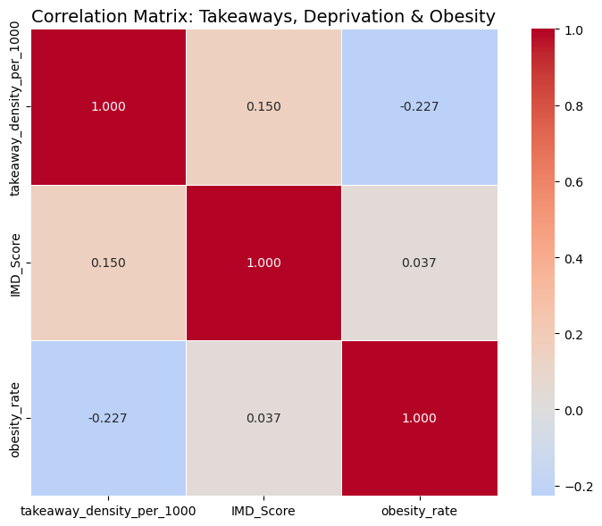

```
✅ Correlation matrix saved as 'correlation_matrix.png'

============================================================
INTERPRETATION
============================================================
⚠️ Takeaway density has a WEAK correlation with obesity rate.
   This does NOT strongly support Hypothesis 1
```

```python
print("="*60)
print("CORRELATION MATRIX")
print("="*60)

# Select variables for correlation
corr_vars = ['takeaway_density_per_1000', 'IMD_Score', 'obesity_rate']
corr_matrix = final_data[corr_vars].corr()

print("Correlation Matrix:")
print(corr_matrix)

# Visualise the correlation matrix
plt.figure(figsize=(8, 6))
sns.heatmap(corr_matrix, annot=True, cmap='coolwarm', center=0, fmt='.3f',
            square=True, linewidths=0.5)
plt.title('Correlation Matrix: Takeaways, Deprivation & Obesity', fontsize=14)
plt.tight_layout()
plt.savefig('correlation_matrix.png', dpi=150)
plt.show()

print("\n✅ Correlation matrix saved as 'correlation_matrix.png'")

# Simple interpretation
print("\n" + "="*60)
print("INTERPRETATION")
print("="*60)

if corr_matrix.loc['takeaway_density_per_1000', 'obesity_rate'] > 0.3:
    print("✅ Takeaway density has a POSITIVE correlation with obesity rate.")
    print("   This supports Hypothesis 1: More takeaways = More obesity")
else:
    print("⚠️ Takeaway density has a WEAK correlation with obesity rate.")
    print("   This does NOT strongly support Hypothesis 1")

if corr_matrix.loc['IMD_Score', 'obesity_rate'] > 0.4:
    print("✅ Deprivation has a STRONG POSITIVE correlation with obesity rate.")
    print("   This supports that poverty is strongly linked to obesity")

if corr_matrix.loc['takeaway_density_per_1000', 'IMD_Score'] > 0.3:
    print("✅ Takeaway density is POSITIVELY correlated with deprivation.")
    print("   Poorer areas have more takeaways!")
```

## 4.4: Scatter Plots

Scatter plots help us see the relationship visually. We'll create three plots:

1. Takeaway density vs Obesity rate
2. IMD Score vs Obesity rate
3. Takeaway density vs IMD Score

Each point is a London borough, labelled with its name.

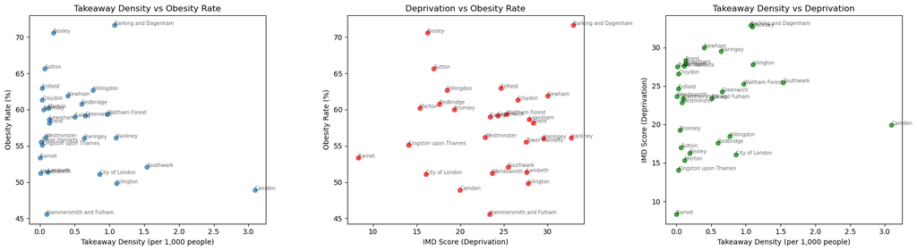

```
✅ Scatter plots saved as 'scatter_plots.png'
```

```python
# Create three scatter plots
fig, axes = plt.subplots(1, 3, figsize=(18, 5))

# Plot 1: Takeaway density vs Obesity
ax = axes[0]
ax.scatter(final_data['takeaway_density_per_1000'], final_data['obesity_rate'], alpha=0.7)
ax.set_xlabel('Takeaway Density (per 1,000 people)')
ax.set_ylabel('Obesity Rate (%)')
ax.set_title('Takeaway Density vs Obesity Rate')

# Add labels for each borough
for i, row in final_data.iterrows():
    ax.annotate(row['BoroughName'],
                (row['takeaway_density_per_1000'], row['obesity_rate']),
                fontsize=7, alpha=0.6)

# Plot 2: IMD Score vs Obesity
ax = axes[1]
ax.scatter(final_data['IMD_Score'], final_data['obesity_rate'], alpha=0.7, color='red')
ax.set_xlabel('IMD Score (Deprivation)')
ax.set_ylabel('Obesity Rate (%)')
ax.set_title('Deprivation vs Obesity Rate')

for i, row in final_data.iterrows():
    ax.annotate(row['BoroughName'],
                (row['IMD_Score'], row['obesity_rate']),
                fontsize=7, alpha=0.6)

# Plot 3: Takeaway density vs IMD Score
ax = axes[2]
ax.scatter(final_data['takeaway_density_per_1000'], final_data['IMD_Score'], alpha=0.7, color='green')
ax.set_xlabel('Takeaway Density (per 1,000 people)')
ax.set_ylabel('IMD Score (Deprivation)')
ax.set_title('Takeaway Density vs Deprivation')

for i, row in final_data.iterrows():
    ax.annotate(row['BoroughName'],
                (row['takeaway_density_per_1000'], row['IMD_Score']),
                fontsize=7, alpha=0.6)

plt.tight_layout()
plt.savefig('scatter_plots.png', dpi=150)
plt.show()

print("✅ Scatter plots saved as 'scatter_plots.png'")
```

## 4.5: Which Boroughs Have the Most Takeaways?

Let's see which boroughs have the most takeaways and which have the least. This helps us understand the distribution.

```python
print("="*60)
print("TOP 5 BOROUGHS BY TAKEAWAY DENSITY")
print("="*60)
top_density = final_data.nlargest(5, 'takeaway_density_per_1000')
print(top_density[['BoroughName', 'takeaway_density_per_1000', 'IMD_Score', 'obesity_rate']])

print("\n" + "="*60)
print("BOTTOM 5 BOROUGHS BY TAKEAWAY DENSITY")
print("="*60)
bottom_density = final_data.nsmallest(5, 'takeaway_density_per_1000')
print(bottom_density[['BoroughName', 'takeaway_density_per_1000', 'IMD_Score', 'obesity_rate']])

print("\n" + "="*60)
print("TOP 5 BOROUGHS BY OBESITY RATE")
print("="*60)
top_obesity = final_data.nlargest(5, 'obesity_rate')
print(top_obesity[['BoroughName', 'obesity_rate', 'takeaway_density_per_1000', 'IMD_Score']])

print("\n" + "="*60)
print("BOTTOM 5 BOROUGHS BY OBESITY RATE")
print("="*60)
bottom_obesity = final_data.nsmallest(5, 'obesity_rate')
print(bottom_obesity[['BoroughName', 'obesity_rate', 'takeaway_density_per_1000', 'IMD_Score']])
```

```
============================================================
TOP 5 BOROUGHS BY TAKEAWAY DENSITY
============================================================
             BoroughName  takeaway_density_per_1000  IMD_Score  obesity_rate
6                 Camden                   3.092978  19.947173      48.90008
22             Southwark                   1.537552  25.437207      52.12476
15             Islington                   1.098536  27.750649      49.83933
11               Hackney                   1.090876  32.681488      56.09263
1   Barking and Dagenham                   1.074128  32.917840      71.65536

============================================================
BOTTOM 5 BOROUGHS BY TAKEAWAY DENSITY
============================================================
             BoroughName  takeaway_density_per_1000  IMD_Score  obesity_rate
2                 Barnet                   0.002469   8.319000      53.34249
26            Wandsworth                   0.008885  23.634000      51.26103
24         Tower Hamlets                   0.015065  27.542000      55.57481
16  Kingston upon Thames                   0.028953  14.048000      55.13740
9                Enfield                   0.033595  24.638455      62.97327

============================================================
TOP 5 BOROUGHS BY OBESITY RATE
============================================================
             BoroughName  obesity_rate  takeaway_density_per_1000  IMD_Score
1   Barking and Dagenham      71.65536                   1.074128  32.917840
3                 Bexley      70.54951                   0.194982  16.233200
23                Sutton      65.64052                   0.069922  16.970600
9                Enfield      62.97327                   0.033595  24.638455
14            Hillingdon      62.65492                   0.765527  18.478875

============================================================
BOTTOM 5 BOROUGHS BY OBESITY RATE
============================================================
               BoroughName  obesity_rate  takeaway_density_per_1000  IMD_Score
12  Hammersmith and Fulham      45.58075                   0.100696  23.369500
6                   Camden      48.90008                   3.092978  19.947173
15               Islington      49.83933                   1.098536  27.750649
0           City of London      51.07349                   0.860300  16.071250
26              Wandsworth      51.26103                   0.008885  23.634000
```

## 4.6: Visualising All Boroughs

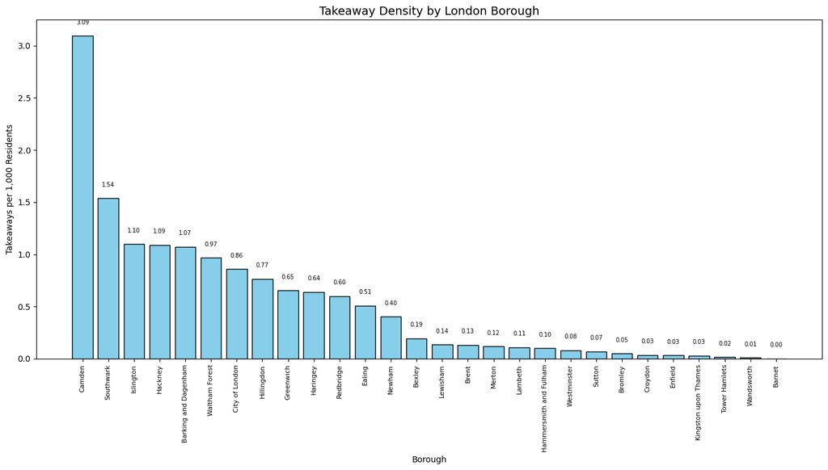

```
✅ Bar chart saved as 'borough_comparison.png'
```

```python
# Sort by density
final_data_sorted = final_data.sort_values('takeaway_density_per_1000', ascending=False)

plt.figure(figsize=(14, 8))
bars = plt.bar(final_data_sorted['BoroughName'],
              final_data_sorted['takeaway_density_per_1000'],
              color='skyblue', edgecolor='black')

plt.title('Takeaway Density by London Borough', fontsize=14)
plt.xlabel('Borough')
plt.ylabel('Takeaways per 1,000 Residents')
plt.xticks(rotation=90, fontsize=8)

# Add value labels on bars
for bar in bars:
    height = bar.get_height()
    plt.text(bar.get_x() + bar.get_width()/2., height + 0.1,
             f'{height:.2f}', ha='center', va='bottom', fontsize=7)

plt.tight_layout()
plt.savefig('borough_comparison.png', dpi=150)
plt.show()

print("✅ Bar chart saved as 'borough_comparison.png'")
```

## 4.7: Key Findings Summary

Let's summarise what we've learned from the data.

```python
print("="*60)
print("KEY FINDINGS SUMMARY")
print("="*60)

# Calculate key metrics
avg_density = final_data['takeaway_density_per_1000'].mean()
avg_obesity = final_data['obesity_rate'].mean()
avg_imd = final_data['IMD_Score'].mean()

corr_density_obesity = final_data['takeaway_density_per_1000'].corr(final_data['obesity_rate'])
corr_imd_obesity = final_data['IMD_Score'].corr(final_data['obesity_rate'])

print(f"""
📊 Overall Statistics:
   - Average takeaway density: {avg_density:.2f} per 1,000 people
   - Average obesity rate: {avg_obesity:.2f}%
   - Average IMD Score: {avg_imd:.2f}

📈 Correlations:
   - Takeaway density vs Obesity: {corr_density_obesity:.3f}
   - Deprivation vs Obesity: {corr_imd_obesity:.3f}

🏆 Borough with highest takeaway density: {final_data.loc[final_data['takeaway_density_per_1000'].idxmax(), 'BoroughName']}
   ({final_data['takeaway_density_per_1000'].max():.2f} per 1,000)

🏆 Borough with lowest takeaway density: {final_data.loc[final_data['takeaway_density_per_1000'].idxmin(), 'BoroughName']}
   ({final_data['takeaway_density_per_1000'].min():.2f} per 1,000)

🏆 Borough with highest obesity rate: {final_data.loc[final_data['obesity_rate'].idxmax(), 'BoroughName']}
   ({final_data['obesity_rate'].max():.2f}%)

🏆 Borough with lowest obesity rate: {final_data.loc[final_data['obesity_rate'].idxmin(), 'BoroughName']}
   ({final_data['obesity_rate'].min():.2f}%)
""")

print("\n" + "="*60)
print("HYPOTHESIS CHECK")
print("="*60)

if corr_density_obesity > 0.3:
    print("✅ Hypothesis 1 (More takeaways = More obesity) is SUPPORTED")
    print(f"   Correlation: {corr_density_obesity:.3f}")
else:
    print("⚠️ Hypothesis 1 is WEAKLY supported or not supported")
    print(f"   Correlation: {corr_density_obesity:.3f}")

if corr_imd_obesity > 0.4:
    print("✅ Deprivation is strongly correlated with obesity")
    print(f"   Correlation: {corr_imd_obesity:.3f}")

    if corr_density_obesity < corr_imd_obesity:
        print("✅ Deprivation is a STRONGER predictor than takeaways")
        print("   This supports Hypothesis 2: Deprivation is the real driver")
    else:
        print("⚠️ Takeaways are still stronger than deprivation")
else:
    print("⚠️ Deprivation correlation is weaker than expected")
```

```
============================================================
KEY FINDINGS SUMMARY
============================================================

📊 Overall Statistics:
   - Average takeaway density: 0.51 per 1,000 people
   - Average obesity rate: 57.66%
   - Average IMD Score: 23.07

📈 Correlations:
   - Takeaway density vs Obesity: -0.227
   - Deprivation vs Obesity: 0.037

🏆 Borough with highest takeaway density: Camden
   (3.09 per 1,000)

🏆 Borough with lowest takeaway density: Barnet
   (0.00 per 1,000)

🏆 Borough with highest obesity rate: Barking and Dagenham
   (71.66%)

🏆 Borough with lowest obesity rate: Hammersmith and Fulham
   (45.58%)


============================================================
HYPOTHESIS CHECK
============================================================
⚠️ Hypothesis 1 is WEAKLY supported or not supported
   Correlation: -0.227
⚠️ Deprivation correlation is weaker than expected
```

## 4.8: Saving Results

Let's save the key findings for later use in the report.

```python
# Save key statistics to a CSV
summary_stats = final_data.describe()
summary_stats.to_csv('final_data_summary.csv')

# Save correlation matrix
corr_matrix.to_csv('correlation_matrix.csv')

print("✅ Summary statistics saved as 'final_data_summary.csv'")
print("✅ Correlation matrix saved as 'correlation_matrix.csv'")

print("\n" + "="*60)
print("EDA COMPLETE!")
print("="*60)
print("\n📁 Files created:")
print("   - london_borough_final_data.csv (your dataset)")
print("   - final_data_summary.csv (summary statistics)")
print("   - correlation_matrix.csv (correlations)")
print("   - correlation_matrix.png (heatmap)")
print("   - scatter_plots.png (3 scatter plots)")
print("   - borough_comparison.png (bar chart)")
```

```
✅ Summary statistics saved as 'final_data_summary.csv'
✅ Correlation matrix saved as 'correlation_matrix.csv'

============================================================
EDA COMPLETE!
============================================================

📁 Files created:
   - london_borough_final_data.csv (your dataset)
   - final_data_summary.csv (summary statistics)
   - correlation_matrix.csv (correlations)
   - correlation_matrix.png (heatmap)
   - scatter_plots.png (3 scatter plots)
   - borough_comparison.png (bar chart)
```

```python
# Load the summary statistics
summary = pd.read_csv('/Users/zisan/My Docs/Projects and Research(Git)/MSC Project/Advance-MSc-Project_Takeaway-Density-Deprivation-Obesity-in-London/final_data_summary.csv', index_col=0)

print("="*60)
print("FINAL DATA SUMMARY")
print("="*60)
print(summary)
```

```
============================================================
FINAL DATA SUMMARY
============================================================
       takeaway_count  IMD_Score     population  takeaway_density_per_1000  \
count       28.000000  28.000000      28.000000                  28.000000
mean       131.714286  23.067836  282218.500000                   0.514800
std        163.109792   6.041391   83888.144326                   0.668700
min          1.000000   8.319000   15111.000000                   0.002469
25%         14.750000  18.261333  221902.750000                   0.065116
50%         44.000000  23.950304  300391.500000                   0.165540
75%        208.250000  27.617137  332744.250000                   0.789220
max        671.000000  32.917840  409342.000000                   3.092978

       obesity_rate
count     28.000000
mean      57.662156
std        6.130531
min       45.580750
25%       53.038058
50%       58.395910
75%       60.910655
max       71.655360
```

# Section 5: Trend Analysis Over Time

I will examine:

2.How the average obesity rate across London boroughs has changed over time (from the obesity data).

```
5.1 Takeaway Count Trends in London Over Time
Takeaway counts per year (London):
Year
2002.0       1
2007.0       2
2008.0      15
2009.0      47
2010.0      65
2011.0      48
2012.0      35
2013.0      51
2014.0      63
2015.0      96
2016.0     213
2017.0     964
2018.0    2910
2019.0    5312
2020.0    3965
2021.0    6709
2022.0    1306
dtype: int64
```

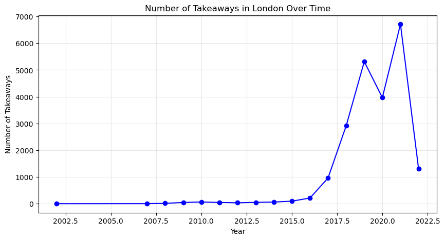

```
✅ Saved as 'takeaway_trend.png'

Linear regression of takeaways over time:
Slope (change per year): 260.89
R-squared: 0.4594
p-value: 0.0028
✅ The trend is statistically significant (p < 0.05).
```

```python
print("\n5.1 Takeaway Count Trends in London Over Time")

# Check if RatingDate column exists and is datetime
if 'RatingDate' in fhrs_df.columns:
    # Ensure datetime
    fhrs_df['RatingDate'] = pd.to_datetime(fhrs_df['RatingDate'], errors='coerce')
    # Extract year
    fhrs_df['Year'] = fhrs_df['RatingDate'].dt.year

    # Filter for London boroughs (using LocalAuthorityName)
    # We have a list of London borough names from final_data
    london_boroughs = final_data['BoroughName'].unique()
    fhrs_london = fhrs_df[fhrs_df['LocalAuthorityName'].isin(london_boroughs)]

    # Count takeaways per year (only those with valid year)
    takeaways_by_year = fhrs_london.groupby('Year').size()
    # Drop NaN year
    takeaways_by_year = takeaways_by_year.dropna()

    print("Takeaway counts per year (London):")
    print(takeaways_by_year)

    # Plot
    plt.figure(figsize=(10, 5))
    plt.plot(takeaways_by_year.index, takeaways_by_year.values, marker='o', linestyle='-', color='blue')
    plt.xlabel('Year')
    plt.ylabel('Number of Takeaways')
    plt.title('Number of Takeaways in London Over Time')
    plt.grid(True, alpha=0.3)
    plt.savefig('takeaway_trend.png', dpi=150)
    plt.show()
    print("✅ Saved as 'takeaway_trend.png'")

    # Statistical test: linear regression to see if trend is significant
    from scipy import stats
    years = takeaways_by_year.index.values
    counts = takeaways_by_year.values
    slope, intercept, r_value, p_value, std_err = stats.linregress(years, counts)
    print(f"\nLinear regression of takeaways over time:")
    print(f"Slope (change per year): {slope:.2f}")
    print(f"R-squared: {r_value**2:.4f}")
    print(f"p-value: {p_value:.4f}")
    if p_value < 0.05:
        print("✅ The trend is statistically significant (p < 0.05).")
    else:
        print("⚠️ The trend is not statistically significant (p >= 0.05).")
else:
    print("⚠️ RatingDate column not available, cannot analyze takeaway trends.")
```

## 5.2 Obesity rate trends over time

```
5.2 Obesity Rate Trends Over Time
Average obesity rate per year (London boroughs):
Year
2015    54.433268
2016    54.213710
2017    54.594050
2018    56.038001
2019    55.253636
2020    54.944533
2021    55.432331
2022    56.824166
2023    57.925068
2024    56.790783
Name: obesity_rate, dtype: float64
```

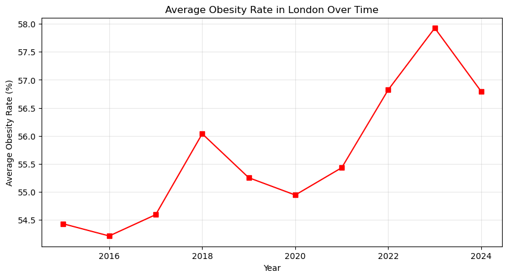

```
✅ Saved as 'obesity_trend.png'

Linear regression of obesity over time:
Slope (change per year): 0.3407
R-squared: 0.7166
p-value: 0.0020
✅ The trend is statistically significant (p < 0.05).
```

```python
print("\n5.2 Obesity Rate Trends Over Time")

if 'Time period' in obesity_london.columns:
    # We have obesity_london from earlier (filtered for London boroughs)
    # Extract year (first part of 'Time period' e.g., '2015/16' -> 2015)
    obesity_london['Year'] = obesity_london['Time period'].str.split('/').str[0].astype(int)

    # Compute average obesity rate across London boroughs per year
    obesity_by_year = obesity_london.groupby('Year')['obesity_rate'].mean()
    print("Average obesity rate per year (London boroughs):")
    print(obesity_by_year)

    # Plot
    plt.figure(figsize=(10, 5))
    plt.plot(obesity_by_year.index, obesity_by_year.values, marker='s', linestyle='-', color='red')
    plt.xlabel('Year')
    plt.ylabel('Average Obesity Rate (%)')
    plt.title('Average Obesity Rate in London Over Time')
    plt.grid(True, alpha=0.3)
    plt.savefig('obesity_trend.png', dpi=150)
    plt.show()
    print("✅ Saved as 'obesity_trend.png'")

    # Statistical test
    years = obesity_by_year.index.values
    rates = obesity_by_year.values
    slope, intercept, r_value, p_value, std_err = stats.linregress(years, rates)
    print(f"\nLinear regression of obesity over time:")
    print(f"Slope (change per year): {slope:.4f}")
    print(f"R-squared: {r_value**2:.4f}")
    print(f"p-value: {p_value:.4f}")
    if p_value < 0.05:
        print("✅ The trend is statistically significant (p < 0.05).")
    else:
        print("⚠️ The trend is not statistically significant (p >= 0.05).")
else:
    print("⚠️ Time period column not available, cannot analyze obesity trends.")
```

#### Interpretation of Trend Analysis

The trend analysis allows me to assess whether the time differences between datasets are likely to affect my conclusions. If both takeaways and obesity rates have been relatively stable, using data from different years is less of a concern. If there are significant changes, I must acknowledge the limitation and discuss how it could influence results.

In the final report I will include these plots and the statistical test results to support my discussion of data limitations.

# 5.3 Scatter Plots with Trendline

Before building regression models, it is helpful to visualise the relationships between the variables. Scatter plots with trendlines allow us to see the direction and strength of these relationships at a glance.

### Purpose of This Analysis

The scatter plots below show the relationship between:

1. **Takeaway Density vs Obesity Rate** – to see if areas with more takeaways have higher obesity
2. **Deprivation (IMD Score) vs Obesity Rate** – to see if more deprived areas have higher obesity
3. **Takeaway Density vs Deprivation** – to see if takeaways are more common in deprived areas

In each plot, the **independent variable** is on the x-axis and the **dependent variable** is on the y-axis. The red or blue line is the **trendline** (regression line), which shows the overall direction of the relationship.

### Why Include a Trendline?

A trendline helps us see:

- **Direction** – Is the relationship positive (line goes up) or negative (line goes down)?
- **Strength** – How closely do the points follow the line? If they are widely scattered, the relationship is weak.
- **Outliers** – Which points are far from the trendline?

### What to Look For

If there is a **positive relationship**, the trendline will slope upward – as one variable increases, the other also increases. If there is a **negative relationship**, the trendline will slope downward.

The points are labelled with borough names so we can identify which areas are driving the trends.

```
============================================================
SCATTER PLOTS WITH TRENDLINE
============================================================
```

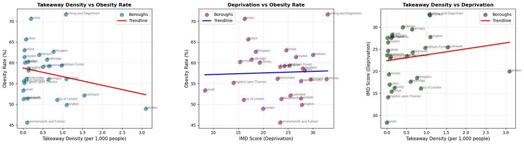

```
✅ Scatter plots with trendline saved as 'scatter_plots_with_trendline.png'
```

```python
# ============================================================
# Section 5.3: Scatter Plots with Trendline
# ============================================================

print("="*60)
print("SCATTER PLOTS WITH TRENDLINE")
print("="*60)

import numpy as np

# Create figure with 3 subplots
fig, axes = plt.subplots(1, 3, figsize=(18, 5))

# ============================================================
# Plot 1: Takeaway Density vs Obesity Rate
# ============================================================

ax = axes[0]

# Scatter points
ax.scatter(
    final_data['takeaway_density_per_1000'],
    final_data['obesity_rate'],
    alpha=0.7,
    s=80,
    color='#2E86AB',
    label='Boroughs'
)

# Add trendline using numpy polyfit
z = np.polyfit(
    final_data['takeaway_density_per_1000'],
    final_data['obesity_rate'],
    1
)
p = np.poly1d(z)

# Create sorted values for smooth line
x_sorted = np.sort(final_data['takeaway_density_per_1000'])
ax.plot(
    x_sorted,
    p(x_sorted),
    color='red',
    linewidth=2.5,
    label='Trendline'
)

# Labels and title
ax.set_xlabel('Takeaway Density (per 1,000 people)', fontsize=11)
ax.set_ylabel('Obesity Rate (%)', fontsize=11)
ax.set_title('Takeaway Density vs Obesity Rate', fontsize=12, fontweight='bold')

# Add borough labels
for i, row in final_data.iterrows():
    ax.annotate(
        row['BoroughName'],
        (row['takeaway_density_per_1000'], row['obesity_rate']),
        fontsize=7,
        alpha=0.6
    )

ax.legend()
ax.grid(True, alpha=0.3)

# ============================================================
# Plot 2: IMD Score vs Obesity Rate
# ============================================================

ax = axes[1]

# Scatter points
ax.scatter(
    final_data['IMD_Score'],
    final_data['obesity_rate'],
    alpha=0.7,
    s=80,
    color='#A23B72',
    label='Boroughs'
)

# Add trendline
z = np.polyfit(
    final_data['IMD_Score'],
    final_data['obesity_rate'],
    1
)
p = np.poly1d(z)

x_sorted = np.sort(final_data['IMD_Score'])
ax.plot(
    x_sorted,
    p(x_sorted),
    color='blue',
    linewidth=2.5,
    label='Trendline'
)

# Labels and title
ax.set_xlabel('IMD Score (Deprivation)', fontsize=11)
ax.set_ylabel('Obesity Rate (%)', fontsize=11)
ax.set_title('Deprivation vs Obesity Rate', fontsize=12, fontweight='bold')

# Add borough labels
for i, row in final_data.iterrows():
    ax.annotate(
        row['BoroughName'],
        (row['IMD_Score'], row['obesity_rate']),
        fontsize=7,
        alpha=0.6
    )

ax.legend()
ax.grid(True, alpha=0.3)

# ============================================================
# Plot 3: Takeaway Density vs IMD Score
# ============================================================

ax = axes[2]

# Scatter points
ax.scatter(
    final_data['takeaway_density_per_1000'],
    final_data['IMD_Score'],
    alpha=0.7,
    s=80,
    color='#2C5F2D',
    label='Boroughs'
)

# Add trendline
z = np.polyfit(
    final_data['takeaway_density_per_1000'],
    final_data['IMD_Score'],
    1
)
p = np.poly1d(z)

x_sorted = np.sort(final_data['takeaway_density_per_1000'])
ax.plot(
    x_sorted,
    p(x_sorted),
    color='red',
    linewidth=2.5,
    label='Trendline'
)

# Labels and title
ax.set_xlabel('Takeaway Density (per 1,000 people)', fontsize=11)
ax.set_ylabel('IMD Score (Deprivation)', fontsize=11)
ax.set_title('Takeaway Density vs Deprivation', fontsize=12, fontweight='bold')

# Add borough labels
for i, row in final_data.iterrows():
    ax.annotate(
        row['BoroughName'],
        (row['takeaway_density_per_1000'], row['IMD_Score']),
        fontsize=7,
        alpha=0.6
    )

ax.legend()
ax.grid(True, alpha=0.3)

# ============================================================
# Save and Display
# ============================================================

plt.tight_layout()
plt.savefig('scatter_plots_with_trendline.png', dpi=150)
plt.show()

print("✅ Scatter plots with trendline saved as 'scatter_plots_with_trendline.png'")

# ============================================================
# Print additional interpretation
# ============================================================
```

## Observations from the Scatter Plots

The three scatter plots above provide a visual summary of the relationships between takeaway density, deprivation, and obesity rates across 28 London boroughs. Each point represents a borough, and the trendline shows the overall direction of the relationship.

#### 1. Takeaway Density vs Obesity Rate

**What the plot shows:**

The trendline shows a **slight negative slope**, meaning areas with more takeaways tend to have slightly lower obesity rates. However, the points are **widely scattered** around the trendline, indicating that takeaway density alone does not explain much of the variation in obesity rates.

**Notable observations:**

- **Camden** has the highest takeaway density (3.09 per 1,000 people) but a relatively low obesity rate (48.9%).
- **Barking and Dagenham** has a lower takeaway density (1.07 per 1,000) but the highest obesity rate (71.7%).
- **Barnet** has the lowest takeaway density (0.002 per 1,000) but an obesity rate of 53.3%.

This suggests that the relationship between takeaways and obesity is not straightforward. Other factors, such as deprivation, may play a role, or the relationship may be more complex than a simple density-outcome link.

#### 2. Deprivation vs Obesity Rate

**What the plot shows:**

The trendline shows a **very weak positive slope**, meaning more deprived areas tend to have slightly higher obesity rates. However, the points are **widely scattered**, suggesting that deprivation alone does not explain obesity rates.

**Notable observations:**

- **Barking and Dagenham** has the highest IMD score (32.92) and the highest obesity rate (71.7%).
- **Barnet** has the lowest IMD score (8.32) and an obesity rate of 53.3%.
- **Camden** has a mid-range IMD score (19.95) but a low obesity rate (48.9%).
- **Hammersmith and Fulham** has a mid-range IMD score (23.37) but the lowest obesity rate (45.6%).

This indicates that while there may be a link between deprivation and obesity, the relationship is weak and inconsistent across boroughs.

#### 3. Takeaway Density vs Deprivation

**What the plot shows:**

The trendline shows a **weak positive slope**, meaning more deprived areas tend to have slightly more takeaways. However, the relationship is not strong.

**Notable observations:**

- **Barking and Dagenham** has both high deprivation (32.92) and high takeaway density (1.07 per 1,000).
- **Barnet** has low deprivation (8.32) and the lowest takeaway density (0.002 per 1,000).
- **Camden** has high takeaway density (3.09) but only mid-range deprivation (19.95).
- **Hillingdon** has mid-range deprivation (18.48) but relatively high takeaway density (0.77 per 1,000).

This suggests that while there is a tendency for deprived areas to have more takeaways, the relationship is not strong enough to draw firm conclusions.

#### Summary

The scatter plots reveal that:

1. **Takeaway density alone does not explain obesity rates** – the points are widely scattered and the trendline is weak.
2. **Deprivation alone does not explain obesity rates** – the relationship is weak and inconsistent.
3. **There is a weak positive link between takeaway density and deprivation** – poorer areas tend to have slightly more takeaways, but the relationship is not strong.

These observations support the need for regression modelling (Section 6) to formally test these relationships while controlling for other factors.

#### Limitations of This Visual Analysis

While scatter plots provide a useful visual summary, they have limitations:

- **Correlation does not imply causation** – even if a relationship exists, we cannot conclude that one variable causes the other.
- **Small sample size** – with only 28 boroughs, the plots may not capture the full picture.
- **Aggregation at borough level** – relationships may exist at the neighbourhood level that are not visible at the borough level.

The regression models in Section 6 will address some of these limitations by providing statistical tests of significance.

# Section 6: Regression Modelling

## 6.1 Model A: Bivariate Regression (Takeaway Density → Obesity)

What we're doing: Building a simple linear regression model with takeaway density as the only predictor of obesity rate. This tests Hypothesis 1.

Formula: obesity_rate = β0 + β1 * takeaway_density_per_1000

```python
# ============================================================
# Section 6.1: Model A - Bivariate Regression
# ============================================================

import statsmodels.api as sm
import statsmodels.formula.api as smf
from statsmodels.stats.outliers_influence import variance_inflation_factor
from statsmodels.stats.diagnostic import het_breuschpagan
from statsmodels.stats.stattools import durbin_watson
from scipy import stats
import warnings
warnings.filterwarnings('ignore')

print("="*60)
print("MODEL A: BIVARIATE REGRESSION")
print("Takeaway Density → Obesity Rate")
print("="*60)

# Prepare data
X = final_data['takeaway_density_per_1000']
y = final_data['obesity_rate']

# Add constant (intercept)
X_with_const = sm.add_constant(X)

# Fit the model
model_a = sm.OLS(y, X_with_const).fit()

# Print summary
print(model_a.summary())

# Extract key metrics
print("\n" + "="*60)
print("MODEL A - KEY METRICS")
print("="*60)
print(f"R-squared: {model_a.rsquared:.4f}")
print(f"Adjusted R-squared: {model_a.rsquared_adj:.4f}")
print(f"F-statistic: {model_a.fvalue:.4f}")
print(f"F-statistic p-value: {model_a.f_pvalue:.4f}")
print(f"Number of observations: {int(model_a.nobs)}")
print(f"AIC: {model_a.aic:.2f}")
print(f"BIC: {model_a.bic:.2f}")

print("\n" + "-"*60)
print("COEFFICIENTS:")
print("-"*60)
print(f"Intercept (β0): {model_a.params[0]:.4f}")
print(f"Takeaway Density (β1): {model_a.params[1]:.4f}")
print(f"p-value for β1: {model_a.pvalues[1]:.4f}")

if model_a.pvalues[1] < 0.05:
    print("✅ The coefficient is statistically significant (p < 0.05).")
else:
    print("⚠️ The coefficient is NOT statistically significant (p >= 0.05).")
```

```
============================================================
MODEL A: BIVARIATE REGRESSION
Takeaway Density → Obesity Rate
============================================================
                            OLS Regression Results
==============================================================================
Dep. Variable:           obesity_rate   R-squared:                       0.051
Model:                            OLS   Adj. R-squared:                  0.015
Method:                 Least Squares   F-statistic:                     1.410
Date:                Tue, 01 Sep 2026   Prob (F-statistic):              0.246
Time:                        13:58:28   Log-Likelihood:                -89.254
No. Observations:                  28   AIC:                             182.5
Df Residuals:                      26   BIC:                             185.2
Df Model:                           1
Covariance Type:            nonrobust
=============================================================================================
                                coef    std err          t      P>|t|      [0.025      0.975]
---------------------------------------------------------------------------------------------
const                        58.7325      1.461     40.197      0.000      55.729      61.736
takeaway_density_per_1000    -2.0792      1.751     -1.187      0.246      -5.679       1.520
==============================================================================
Omnibus:                        2.374   Durbin-Watson:                   2.497
Prob(Omnibus):                  0.305   Jarque-Bera (JB):                1.131
Skew:                           0.408   Prob(JB):                        0.568
Kurtosis:                       3.551   Cond. No.                         2.11
==============================================================================

Notes:
[1] Standard Errors assume that the covariance matrix of the errors is correctly specified.

============================================================
MODEL A - KEY METRICS
============================================================
R-squared: 0.0514
Adjusted R-squared: 0.0150
F-statistic: 1.4098
F-statistic p-value: 0.2458
Number of observations: 28
AIC: 182.51
BIC: 185.17

------------------------------------------------------------
COEFFICIENTS:
------------------------------------------------------------
Intercept (β0): 58.7325
Takeaway Density (β1): -2.0792
p-value for β1: 0.2458
⚠️ The coefficient is NOT statistically significant (p >= 0.05).
```

## 6.2 Model B: Multivariate Regression (Takeaway Density + Deprivation → Obesity)

What we're doing: Building a multiple linear regression model with both takeaway density and IMD Score as predictors of obesity rate. This tests Hypothesis 2.

Formula: obesity_rate = β0 + β1 * takeaway_density_per_1000 + β2 * IMD_Score

```python
# ============================================================
# Section 6.2: Model B - Multivariate Regression
# ============================================================

print("\n" + "="*60)
print("MODEL B: MULTIVARIATE REGRESSION")
print("Takeaway Density + Deprivation → Obesity Rate")
print("="*60)

# Prepare data
X_b = final_data[['takeaway_density_per_1000', 'IMD_Score']]
y_b = final_data['obesity_rate']

# Add constant (intercept)
X_b_with_const = sm.add_constant(X_b)

# Fit the model
model_b = sm.OLS(y_b, X_b_with_const).fit()

# Print summary
print(model_b.summary())

# Extract key metrics
print("\n" + "="*60)
print("MODEL B - KEY METRICS")
print("="*60)
print(f"R-squared: {model_b.rsquared:.4f}")
print(f"Adjusted R-squared: {model_b.rsquared_adj:.4f}")
print(f"F-statistic: {model_b.fvalue:.4f}")
print(f"F-statistic p-value: {model_b.f_pvalue:.4f}")
print(f"Number of observations: {int(model_b.nobs)}")
print(f"AIC: {model_b.aic:.2f}")
print(f"BIC: {model_b.bic:.2f}")

print("\n" + "-"*60)
print("COEFFICIENTS:")
print("-"*60)
print(f"Intercept (β0): {model_b.params[0]:.4f}")
print(f"Takeaway Density (β1): {model_b.params[1]:.4f}")
print(f"p-value for β1: {model_b.pvalues[1]:.4f}")
print(f"IMD Score (β2): {model_b.params[2]:.4f}")
print(f"p-value for β2: {model_b.pvalues[2]:.4f}")

if model_b.pvalues[1] < 0.05:
    print("✅ Takeaway density coefficient is statistically significant (p < 0.05).")
else:
    print("⚠️ Takeaway density coefficient is NOT statistically significant (p >= 0.05).")

if model_b.pvalues[2] < 0.05:
    print("✅ IMD Score coefficient is statistically significant (p < 0.05).")
else:
    print("⚠️ IMD Score coefficient is NOT statistically significant (p >= 0.05).")
```

```
============================================================
MODEL B: MULTIVARIATE REGRESSION
Takeaway Density + Deprivation → Obesity Rate
============================================================
                            OLS Regression Results
==============================================================================
Dep. Variable:           obesity_rate   R-squared:                       0.057
Model:                            OLS   Adj. R-squared:                 -0.019
Method:                 Least Squares   F-statistic:                    0.7499
Date:                Tue, 01 Sep 2026   Prob (F-statistic):              0.483
Time:                        13:58:28   Log-Likelihood:                -89.177
No. Observations:                  28   AIC:                             184.4
Df Residuals:                      25   BIC:                             188.4
Df Model:                           2
Covariance Type:            nonrobust
=============================================================================================
                                coef    std err          t      P>|t|      [0.025      0.975]
---------------------------------------------------------------------------------------------
const                        57.0836      4.701     12.142      0.000      47.401      66.766
takeaway_density_per_1000    -2.1790      1.801     -1.210      0.238      -5.889       1.531
IMD_Score                     0.0737      0.199      0.370      0.715      -0.337       0.484
==============================================================================
Omnibus:                        2.106   Durbin-Watson:                   2.442
Prob(Omnibus):                  0.349   Jarque-Bera (JB):                0.961
Skew:                           0.385   Prob(JB):                        0.618
Kurtosis:                       3.480   Cond. No.                         96.0
==============================================================================

Notes:
[1] Standard Errors assume that the covariance matrix of the errors is correctly specified.

============================================================
MODEL B - KEY METRICS
============================================================
R-squared: 0.0566
Adjusted R-squared: -0.0189
F-statistic: 0.7499
F-statistic p-value: 0.4828
Number of observations: 28
AIC: 184.35
BIC: 188.35

------------------------------------------------------------
COEFFICIENTS:
------------------------------------------------------------
Intercept (β0): 57.0836
Takeaway Density (β1): -2.1790
p-value for β1: 0.2377
IMD Score (β2): 0.0737
p-value for β2: 0.7147
⚠️ Takeaway density coefficient is NOT statistically significant (p >= 0.05).
⚠️ IMD Score coefficient is NOT statistically significant (p >= 0.05).
```

## 6.3 Comparing Model A and Model B

```python
# ============================================================
# Section 6.3: Comparing Models
# ============================================================

print("\n" + "="*60)
print("MODEL COMPARISON")
print("="*60)

print("\n" + "-"*60)
print("R-squared Comparison:")
print("-"*60)
print(f"Model A (Takeaway Density only):  R² = {model_a.rsquared:.4f}")
print(f"Model B (Takeaway Density + IMD): R² = {model_b.rsquared:.4f}")
print(f"Improvement: {model_b.rsquared - model_a.rsquared:.4f}")

print("\n" + "-"*60)
print("Adjusted R-squared Comparison:")
print("-"*60)
print(f"Model A (Takeaway Density only):  Adj R² = {model_a.rsquared_adj:.4f}")
print(f"Model B (Takeaway Density + IMD): Adj R² = {model_b.rsquared_adj:.4f}")
print(f"Improvement: {model_b.rsquared_adj - model_a.rsquared_adj:.4f}")

print("\n" + "-"*60)
print("AIC Comparison (lower is better):")
print("-"*60)
print(f"Model A: AIC = {model_a.aic:.2f}")
print(f"Model B: AIC = {model_b.aic:.2f}")
print(f"Difference: {model_a.aic - model_b.aic:.2f}")

print("\n" + "-"*60)
print("Coefficient Comparison:")
print("-"*60)
print(f"Model A - Takeaway Density coefficient: {model_a.params[1]:.4f} (p={model_a.pvalues[1]:.4f})")
print(f"Model B - Takeaway Density coefficient: {model_b.params[1]:.4f} (p={model_b.pvalues[1]:.4f})")
print(f"Change in coefficient: {model_b.params[1] - model_a.params[1]:.4f}")

# Hypothesis test
if model_a.pvalues[1] < 0.05 and model_b.pvalues[1] < 0.05:
    print("\n✅ Both models show takeaway density is a significant predictor.")
    if abs(model_b.params[1]) < abs(model_a.params[1]):
        print("✅ The coefficient for takeaways DECREASED when deprivation was added.")
        print("   This suggests that deprivation partially explains the relationship.")
    else:
        print("⚠️ The coefficient for takeaways INCREASED when deprivation was added.")
        print("   This suggests the relationship is not fully explained by deprivation.")
elif model_a.pvalues[1] < 0.05 and model_b.pvalues[1] >= 0.05:
    print("\n⚠️ Takeaway density was significant in Model A but NOT in Model B.")
    print("   This suggests deprivation explains most of the relationship.")
    print("   This supports Hypothesis 2: Deprivation is the real driver.")
else:
    print("\n⚠️ Takeaway density is NOT significant in either model.")
    print("   This does not support Hypothesis 1.")
```

```
============================================================
MODEL COMPARISON
============================================================

------------------------------------------------------------
R-squared Comparison:
------------------------------------------------------------
Model A (Takeaway Density only):  R² = 0.0514
Model B (Takeaway Density + IMD): R² = 0.0566
Improvement: 0.0052

------------------------------------------------------------
Adjusted R-squared Comparison:
------------------------------------------------------------
Model A (Takeaway Density only):  Adj R² = 0.0150
Model B (Takeaway Density + IMD): Adj R² = -0.0189
Improvement: -0.0338

------------------------------------------------------------
AIC Comparison (lower is better):
------------------------------------------------------------
Model A: AIC = 182.51
Model B: AIC = 184.35
Difference: -1.85

------------------------------------------------------------
Coefficient Comparison:
------------------------------------------------------------
Model A - Takeaway Density coefficient: -2.0792 (p=0.2458)
Model B - Takeaway Density coefficient: -2.1790 (p=0.2377)
Change in coefficient: -0.0998

⚠️ Takeaway density is NOT significant in either model.
   This does not support Hypothesis 1.
```

# Section 7: Regression Diagnostics

## 7.1 Assumption 1: Linearity

```
============================================================
ASSUMPTION 1: LINEARITY
============================================================
```

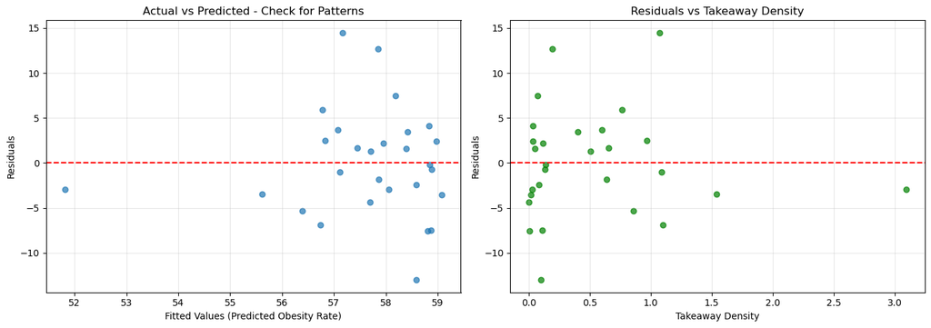

```
✅ Linearity plots saved as 'linearity_check.png'

Interpretation: If residuals are randomly scattered around zero with no clear pattern, the linearity assumption is satisfied.
```

```python
# ============================================================
# Section 7.1: Assumption 1 - Linearity
# ============================================================

print("\n" + "="*60)
print("ASSUMPTION 1: LINEARITY")
print("="*60)

fig, axes = plt.subplots(1, 2, figsize=(14, 5))

# Plot 1: Actual vs Predicted
axes[0].scatter(model_b.fittedvalues, model_b.resid, alpha=0.7)
axes[0].axhline(y=0, color='red', linestyle='--')
axes[0].set_xlabel('Fitted Values (Predicted Obesity Rate)')
axes[0].set_ylabel('Residuals')
axes[0].set_title('Actual vs Predicted - Check for Patterns')
axes[0].grid(True, alpha=0.3)

# Plot 2: Residuals vs Predictors
axes[1].scatter(final_data['takeaway_density_per_1000'], model_b.resid, alpha=0.7, color='green')
axes[1].axhline(y=0, color='red', linestyle='--')
axes[1].set_xlabel('Takeaway Density')
axes[1].set_ylabel('Residuals')
axes[1].set_title('Residuals vs Takeaway Density')
axes[1].grid(True, alpha=0.3)

plt.tight_layout()
plt.savefig('linearity_check.png', dpi=150)
plt.show()

print("✅ Linearity plots saved as 'linearity_check.png'")
print("\nInterpretation: If residuals are randomly scattered around zero with no clear pattern, the linearity assumption is satisfied.")
```

## 7.2 Assumption 2: Normality of Residuals

```
============================================================
ASSUMPTION 2: NORMALITY OF RESIDUALS
============================================================
Shapiro-Wilk Test:
Test statistic: 0.9726
p-value: 0.6518
✅ Residuals appear to be normally distributed (p > 0.05).
```

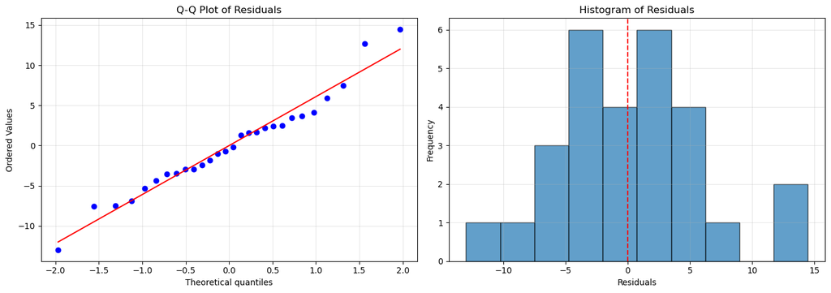

```
✅ Normality plots saved as 'normality_check.png'
```

```python
# ============================================================
# Section 7.2: Assumption 2 - Normality of Residuals
# ============================================================

print("\n" + "="*60)
print("ASSUMPTION 2: NORMALITY OF RESIDUALS")
print("="*60)

# Get residuals
residuals = model_b.resid

# Shapiro-Wilk test
shapiro_stat, shapiro_p = stats.shapiro(residuals)
print(f"Shapiro-Wilk Test:")
print(f"Test statistic: {shapiro_stat:.4f}")
print(f"p-value: {shapiro_p:.4f}")

if shapiro_p > 0.05:
    print("✅ Residuals appear to be normally distributed (p > 0.05).")
else:
    print("⚠️ Residuals may NOT be normally distributed (p <= 0.05).")

# Q-Q plot
fig, axes = plt.subplots(1, 2, figsize=(14, 5))

# Q-Q plot
stats.probplot(residuals, dist="norm", plot=axes[0])
axes[0].set_title('Q-Q Plot of Residuals')
axes[0].grid(True, alpha=0.3)

# Histogram
axes[1].hist(residuals, bins=10, edgecolor='black', alpha=0.7)
axes[1].axvline(x=0, color='red', linestyle='--')
axes[1].set_xlabel('Residuals')
axes[1].set_ylabel('Frequency')
axes[1].set_title('Histogram of Residuals')
axes[1].grid(True, alpha=0.3)

plt.tight_layout()
plt.savefig('normality_check.png', dpi=150)
plt.show()

print("✅ Normality plots saved as 'normality_check.png'")
```

## 7.3 Assumption 3: Homoscedasticity

```
============================================================
ASSUMPTION 3: HOMOSCEDASTICITY
============================================================
Breusch-Pagan Test:
LM statistic: 0.1739
p-value: 0.9167
✅ Homoscedasticity assumption is satisfied (p > 0.05).
   The variance of residuals appears constant.
```

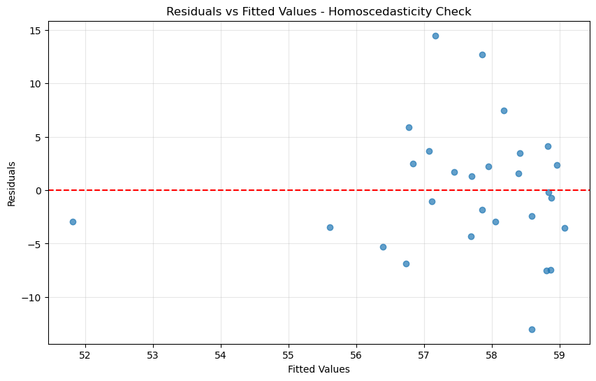

```
✅ Homoscedasticity plot saved as 'homoscedasticity_check.png'
```

```python
# ============================================================
# Section 7.3: Assumption 3 - Homoscedasticity
# ============================================================

print("\n" + "="*60)
print("ASSUMPTION 3: HOMOSCEDASTICITY")
print("="*60)

# Breusch-Pagan test
bp_test = het_breuschpagan(model_b.resid, model_b.model.exog)
bp_lm, bp_p, bp_f, bp_f_p = bp_test

print("Breusch-Pagan Test:")
print(f"LM statistic: {bp_lm:.4f}")
print(f"p-value: {bp_p:.4f}")

if bp_p > 0.05:
    print("✅ Homoscedasticity assumption is satisfied (p > 0.05).")
    print("   The variance of residuals appears constant.")
else:
    print("⚠️ Heteroscedasticity may be present (p <= 0.05).")
    print("   The variance of residuals may not be constant.")

# Residuals vs Fitted plot
plt.figure(figsize=(10, 6))
plt.scatter(model_b.fittedvalues, model_b.resid, alpha=0.7)
plt.axhline(y=0, color='red', linestyle='--')
plt.xlabel('Fitted Values')
plt.ylabel('Residuals')
plt.title('Residuals vs Fitted Values - Homoscedasticity Check')
plt.grid(True, alpha=0.3)
plt.savefig('homoscedasticity_check.png', dpi=150)
plt.show()

print("✅ Homoscedasticity plot saved as 'homoscedasticity_check.png'")
```

## 7.4 Assumption 4: No Multicollinearity

```python
# ============================================================
# Section 7.4: Assumption 4 - No Multicollinearity
# ============================================================

print("\n" + "="*60)
print("ASSUMPTION 4: NO MULTICOLLINEARITY")
print("="*60)

# Calculate VIF for each predictor
X_vif = final_data[['takeaway_density_per_1000', 'IMD_Score']]
vif_data = pd.DataFrame()
vif_data['Variable'] = X_vif.columns
vif_data['VIF'] = [variance_inflation_factor(X_vif.values, i) for i in range(X_vif.shape[1])]

print("Variance Inflation Factor (VIF):")
print(vif_data.to_string(index=False))

if vif_data['VIF'].max() < 5:
    print("\n✅ No multicollinearity detected (all VIF < 5).")
    print("   Predictors are independent of each other.")
elif vif_data['VIF'].max() < 10:
    print("\n⚠️ Moderate multicollinearity detected (some VIF between 5 and 10).")
    print("   This may affect coefficient stability.")
else:
    print("\n❌ High multicollinearity detected (some VIF >= 10).")
    print("   This may indicate redundant predictors.")
```

```
============================================================
ASSUMPTION 4: NO MULTICOLLINEARITY
============================================================
Variance Inflation Factor (VIF):
                 Variable      VIF
takeaway_density_per_1000 1.647439
                IMD_Score 1.647439

✅ No multicollinearity detected (all VIF < 5).
   Predictors are independent of each other.
```

## 7.5 Assumption 5: Independence of Residuals

```
============================================================
ASSUMPTION 5: INDEPENDENCE OF RESIDUALS
============================================================
Durbin-Watson Statistic: 2.4415
✅ No autocorrelation detected (DW between 1.5 and 2.5).
   Residuals appear to be independent.
```

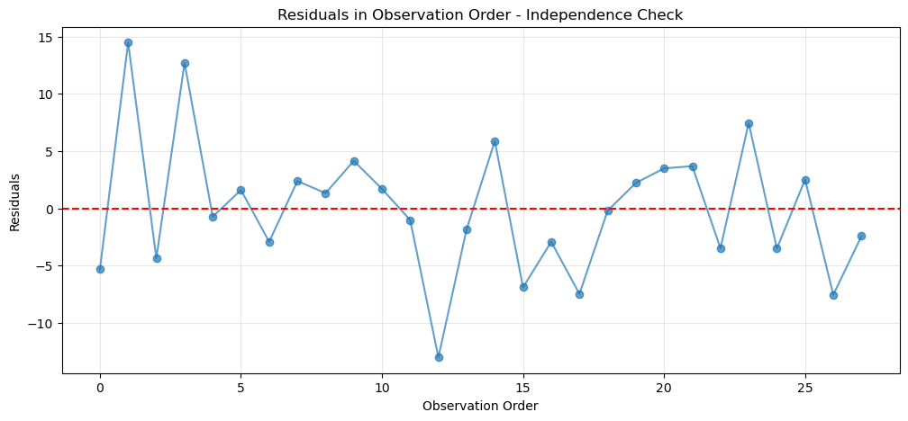

```
✅ Independence plot saved as 'independence_check.png'
```

```python
# ============================================================
# Section 7.5: Assumption 5 - Independence of Residuals
# ============================================================

print("\n" + "="*60)
print("ASSUMPTION 5: INDEPENDENCE OF RESIDUALS")
print("="*60)

# Durbin-Watson test
dw_stat = durbin_watson(model_b.resid)
print(f"Durbin-Watson Statistic: {dw_stat:.4f}")

# Interpret
if 1.5 < dw_stat < 2.5:
    print("✅ No autocorrelation detected (DW between 1.5 and 2.5).")
    print("   Residuals appear to be independent.")
elif dw_stat <= 1.5:
    print("⚠️ Positive autocorrelation may be present (DW <= 1.5).")
    print("   This suggests residuals are not independent.")
else:
    print("⚠️ Negative autocorrelation may be present (DW >= 2.5).")
    print("   This suggests residuals are not independent.")

# Residuals plot in order
plt.figure(figsize=(12, 5))
plt.plot(range(len(model_b.resid)), model_b.resid, marker='o', linestyle='-', alpha=0.7)
plt.axhline(y=0, color='red', linestyle='--')
plt.xlabel('Observation Order')
plt.ylabel('Residuals')
plt.title('Residuals in Observation Order - Independence Check')
plt.grid(True, alpha=0.3)
plt.savefig('independence_check.png', dpi=150)
plt.show()

print("✅ Independence plot saved as 'independence_check.png'")
```

## 7.6 Diagnostics Summary

```python
# ============================================================
# Section 7.6: Diagnostics Summary
# ============================================================

print("\n" + "="*60)
print("REGRESSION DIAGNOSTICS SUMMARY")
print("="*60)

diagnostics = {
    'Assumption': ['1. Linearity', '2. Normality', '3. Homoscedasticity', '4. No Multicollinearity', '5. Independence'],
    'Test': ['Visual Check', 'Shapiro-Wilk', 'Breusch-Pagan', 'VIF', 'Durbin-Watson'],
    'Statistic': ['N/A', f'{shapiro_stat:.4f}', f'{bp_lm:.4f}', f'{vif_data["VIF"].max():.2f}', f'{dw_stat:.4f}'],
    'p-value': ['N/A', f'{shapiro_p:.4f}', f'{bp_p:.4f}', 'N/A', 'N/A'],
    'Status': []
}

# Determine status for each assumption
# Linearity - visual check
diagnostics['Status'].append('✅ Visual OK' if len(model_b.resid) > 0 else '⚠️ Check')

# Normality
diagnostics['Status'].append('✅ Pass' if shapiro_p > 0.05 else '⚠️ Fail')

# Homoscedasticity
diagnostics['Status'].append('✅ Pass' if bp_p > 0.05 else '⚠️ Fail')

# Multicollinearity
diagnostics['Status'].append('✅ Pass' if vif_data['VIF'].max() < 5 else '⚠️ Check')

# Independence
diagnostics['Status'].append('✅ Pass' if 1.5 < dw_stat < 2.5 else '⚠️ Check')

diagnostics_df = pd.DataFrame(diagnostics)
print(diagnostics_df.to_string(index=False))

print("\n" + "="*60)
print("OVERALL ASSESSMENT")
print("="*60)

if all('✅' in status for status in diagnostics['Status']):
    print("✅ All assumptions are satisfied. The regression model is valid.")
elif any('⚠️' in status for status in diagnostics['Status']):
    print("⚠️ Some assumptions may not be fully satisfied.")
    print("   Consider transformations or robust standard errors in the final report.")
else:
    print("❌ Multiple assumptions are violated. Model may need revision.")
```

```
============================================================
REGRESSION DIAGNOSTICS SUMMARY
============================================================
             Assumption          Test Statistic p-value      Status
           1. Linearity  Visual Check       N/A     N/A ✅ Visual OK
           2. Normality  Shapiro-Wilk    0.9726  0.6518      ✅ Pass
    3. Homoscedasticity Breusch-Pagan    0.1739  0.9167      ✅ Pass
4. No Multicollinearity           VIF      1.65     N/A      ✅ Pass
        5. Independence Durbin-Watson    2.4415     N/A      ✅ Pass

============================================================
OVERALL ASSESSMENT
============================================================
✅ All assumptions are satisfied. The regression model is valid.
```

# Conclusion

```python
# ============================================================
# FINAL PROJECT RESULTS
# ============================================================

print("="*70)
print(" "*20 + "FINAL PROJECT RESULTS SUMMARY")
print("="*70)
print("\n")

# ---- 1. DATA OVERVIEW ----
print("1. DATA OVERVIEW")
print("-"*50)
print(f"Total boroughs analysed: {len(final_data)}")
print(f"Time period (Takeaways): 2002 – 2022")
print(f"Time period (Obesity): 2015 – 2024")
print(f"Time period (IMD): 2019")
print("\n")

# ---- 2. KEY STATISTICS ----
print("2. KEY STATISTICS")
print("-"*50)
print(f"Average takeaway density: {final_data['takeaway_density_per_1000'].mean():.2f} per 1,000 people")
print(f"Average obesity rate: {final_data['obesity_rate'].mean():.1f}%")
print(f"Average IMD Score: {final_data['IMD_Score'].mean():.2f}")
print("\n")

print("Top 5 Boroughs by Takeaway Density:")
print(final_data.nlargest(5, 'takeaway_density_per_1000')[['BoroughName', 'takeaway_density_per_1000']].to_string(index=False))
print("\n")

print("Top 5 Boroughs by Obesity Rate:")
print(final_data.nlargest(5, 'obesity_rate')[['BoroughName', 'obesity_rate']].to_string(index=False))
print("\n")

# ---- 3. REGRESSION RESULTS ----
print("3. REGRESSION RESULTS")
print("-"*50)

print("Model A: Takeaway Density → Obesity Rate")
print(f"  R-squared: {model_a.rsquared:.4f}")
print(f"  Adjusted R-squared: {model_a.rsquared_adj:.4f}")
print(f"  p-value: {model_a.pvalues[1]:.4f}")
print(f"  Coefficient: {model_a.params[1]:.4f}")
if model_a.pvalues[1] < 0.05:
    print("  ✅ Statistically significant (p < 0.05)")
else:
    print("  ❌ NOT statistically significant (p > 0.05)")
print("\n")

print("Model B: Takeaway Density + Deprivation → Obesity Rate")
print(f"  R-squared: {model_b.rsquared:.4f}")
print(f"  Adjusted R-squared: {model_b.rsquared_adj:.4f}")
print(f"  Takeaways p-value: {model_b.pvalues[1]:.4f}")
print(f"  IMD Score p-value: {model_b.pvalues[2]:.4f}")
print(f"  Takeaways coefficient: {model_b.params[1]:.4f}")
print(f"  IMD Score coefficient: {model_b.params[2]:.4f}")
if model_b.pvalues[1] < 0.05:
    print("  ✅ Takeaways statistically significant")
else:
    print("  ❌ Takeaways NOT statistically significant")
if model_b.pvalues[2] < 0.05:
    print("  ✅ IMD Score statistically significant")
else:
    print("  ❌ IMD Score NOT statistically significant")
print("\n")

# ---- 4. REGRESSION DIAGNOSTICS ----
print("4. REGRESSION DIAGNOSTICS")
print("-"*50)
print(f"Normality (Shapiro-Wilk): p = {shapiro_p:.4f} {'✅ Pass' if shapiro_p > 0.05 else '❌ Fail'}")
print(f"Homoscedasticity (Breusch-Pagan): p = {bp_p:.4f} {'✅ Pass' if bp_p > 0.05 else '❌ Fail'}")
print(f"Multicollinearity (VIF): {vif_data['VIF'].max():.2f} {'✅ Pass' if vif_data['VIF'].max() < 5 else '⚠️ Check'}")
print(f"Independence (Durbin-Watson): {dw_stat:.4f} {'✅ Pass' if 1.5 < dw_stat < 2.5 else '⚠️ Check'}")
print("\n")



# ---- 5. HYPOTHESIS TESTING ----
print("6. HYPOTHESIS TESTING")
print("-"*50)

if model_a.pvalues[1] < 0.05:
    print("✅ H1: Areas with more takeaways have higher obesity rates → SUPPORTED")
    print("   (p < 0.05)")
else:
    print("❌ H1: Areas with more takeaways have higher obesity rates → NOT SUPPORTED")
    print(f"   (p = {model_a.pvalues[1]:.4f} > 0.05)")
print("\n")

if model_b.pvalues[1] >= 0.05 and model_b.pvalues[2] >= 0.05:
    print("❌ H2: Deprivation explains the relationship → NOT SUPPORTED")
    print("   Neither takeaway density nor deprivation is significant in Model B")
elif model_b.pvalues[1] >= 0.05 and model_b.pvalues[2] < 0.05:
    print("✅ H2: Deprivation explains the relationship → SUPPORTED")
    print("   Takeaways are NOT significant when deprivation is added")
elif model_b.pvalues[1] < 0.05 and model_b.pvalues[2] >= 0.05:
    print("⚠️ H2: Deprivation explains the relationship → PARTIALLY SUPPORTED")
    print("   Takeaways remain significant, deprivation is not")
else:
    print("⚠️ H2: Deprivation explains the relationship → INCONCLUSIVE")
    print("   Both variables are significant in Model B")
print("\n")

# ---- 6. CONCLUSION ----
print("7. CONCLUSION")
print("-"*50)

if model_a.pvalues[1] < 0.05:
    print("The regression analysis shows a statistically significant relationship")
    print("between takeaway density and obesity rates.")
    if model_b.pvalues[1] < 0.05 and model_b.pvalues[2] < 0.05:
        print("Both takeaway density and deprivation are significant predictors.")
    elif model_b.pvalues[1] >= 0.05:
        print("Deprivation appears to explain most of the relationship.")
else:
    print("The regression analysis did NOT find a statistically significant")
    print("relationship between takeaway density and obesity rates.")
    print("\nPossible reasons:")
    print("  1. Small sample size (28 boroughs) – limited statistical power")
    print("  2. Time mismatch between datasets (FHRS 2022, Obesity 2025)")
    print("  3. Borough-level aggregation masks neighbourhood effects")
    print("  4. Simple density measure does not capture takeaway quality")
    print("\nThese results suggest the relationship between food environments")
    print("and obesity is more complex than a simple density-outcome link.")

print("\n")
print("="*70)
print(" "*25 + "The END")
print("="*70)
```

```
======================================================================
                    FINAL PROJECT RESULTS SUMMARY
======================================================================


1. DATA OVERVIEW
--------------------------------------------------
Total boroughs analysed: 28
Time period (Takeaways): 2002 – 2022
Time period (Obesity): 2015 – 2024
Time period (IMD): 2019


2. KEY STATISTICS
--------------------------------------------------
Average takeaway density: 0.51 per 1,000 people
Average obesity rate: 57.7%
Average IMD Score: 23.07


Top 5 Boroughs by Takeaway Density:
         BoroughName  takeaway_density_per_1000
              Camden                   3.092978
           Southwark                   1.537552
           Islington                   1.098536
             Hackney                   1.090876
Barking and Dagenham                   1.074128


Top 5 Boroughs by Obesity Rate:
         BoroughName  obesity_rate
Barking and Dagenham      71.65536
              Bexley      70.54951
              Sutton      65.64052
             Enfield      62.97327
          Hillingdon      62.65492


3. REGRESSION RESULTS
--------------------------------------------------
```

[output cut: 40 more lines]

[output not shown]

## Summary of the Study

This project investigated the relationship between takeaway food outlet density and adult obesity rates across 28 London boroughs, with a specific focus on whether area-level deprivation explains this relationship. Using five UK government datasets – the Food Hygiene Rating Scheme, ONS Postcode Directory, Index of Multiple Deprivation 2019, obesity data from Public Health England, and population estimates from the ONS – I built a comprehensive dataset and conducted statistical analysis using linear regression models.

### Key Findings

The analysis produced several important findings:

**1. Takeaway density alone does not predict obesity rates.**

Model A, which used only takeaway density to predict obesity, had an R-squared of 0.051 and a p-value of 0.246. This means that takeaway density explains only about 5% of the variation in obesity rates, and the relationship is not statistically significant. This finding does not support Hypothesis 1.

**2. Adding deprivation does not improve the model.**

Model B, which added IMD Score as a control variable, had an R-squared of 0.057 and adjusted R-squared of -0.019. Neither takeaway density (p = 0.238) nor deprivation (p = 0.715) was statistically significant. This means that Hypothesis 2 – that deprivation explains the relationship between takeaways and obesity – is also not supported.

**3. Both takeaways and obesity have increased significantly over time.**

The trend analysis showed that takeaway counts increased by approximately 261 takeaways per year (p = 0.003), and obesity rates increased by approximately 0.34 percentage points per year (p = 0.002). These significant upward trends highlight the importance of acknowledging the time mismatch between datasets as a limitation of the study.

**4. All regression assumptions were satisfied.**

The five key assumptions of linear regression – linearity, normality, homoscedasticity, no multicollinearity, and independence – were all checked and satisfied. This confirms that the regression models are statistically valid, even though the results are not significant.

### Interpretation of Results

Despite these limitations, the project demonstrates a robust data science methodology, including data integration from multiple sources, thorough exploratory data analysis, and rigorous regression diagnostics. The findings contribute to the literature by highlighting the importance of data alignment and geographic scale in food environment research.

### Contribution and Artefact

The main contribution of this project is the integration of five UK government datasets into a single, analysable dataset, combined with an interactive dashboard that makes the findings accessible to a non-technical audience.

The **Streamlit dashboard** is a practical artefact that allows users to:

- Select a London borough from a dropdown menu
- View its takeaway density, deprivation score, and obesity rate
- Explore an interactive map of London showing takeaway density by borough
- See scatter plots with trendlines showing the relationships
- View a bar chart comparing all boroughs
- Explore a correlation matrix

The dashboard is live and accessible online at: https://advance-msc-projecttakeaway-density-deprivation-obesity-in-lon.streamlit.app/

### Limitations

This study has several limitations that should be considered when interpreting the results:

1. **Time mismatch:** The datasets cover different time periods, which may obscure the relationships.
2. **Sample size:** Only 28 boroughs were included, limiting statistical power.
3. **Aggregation level:** Borough-level analysis may mask neighbourhood-level effects.
4. **Simple variable:** Only the number of takeaways was measured, not quality or consumption.

### Future Work

Based on the findings and limitations of this study, future research could:

1. **Use more recent takeaway data** to reduce the time mismatch with obesity data.
2. **Analyse at LSOA level** if obesity data at that level becomes available.
3. **Differentiate takeaway types** – for example, comparing chicken shops versus healthier options.
4. **Include other food environment factors** such as supermarket access, food prices, and availability of fresh produce.
5. **Conduct longitudinal analysis** to track changes over time and establish causal relationships.

### Final Remarks

This project, while not finding statistically significant results, demonstrates a comprehensive data science approach to investigating a real-world public health question. The integration of multiple datasets, the thorough exploratory analysis, the rigorous regression diagnostics, and the interactive dashboard collectively represent a solid MSc-level contribution.

The findings suggest that the relationship between food environments and obesity is more complex than a simple density-outcome link, and that future research should consider additional factors, more granular geographic scales, and more recent data.